# Retiring the store flyer: Effects of ceasing print store flyers on household grocery shopping behavior

Converted from PDF `VanLin-RetiringStoreFlyer-2025-TI.pdf` · 64 pages · anchors: page `#pN`, block `#pN-bK`

Page 1

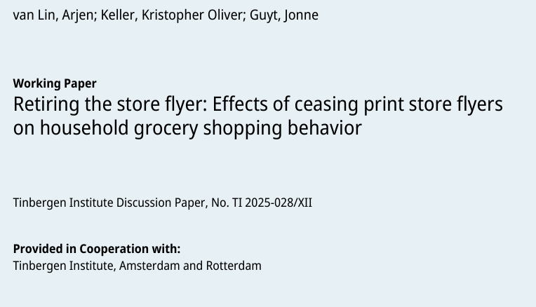

NOTE: figure/graphic rendered as an image from the PDF; its content is not machine-readable text. Caption (if any) follows as the next block.

**text found inside the figure**

van Lin, Arjen; Keller, Kristopher Oliver; Guyt, Jonne

**Working Paper** Retiring the store flyer: Effects of ceasing print store flyers on household grocery shopping behavior

Tinbergen Institute Discussion Paper, No. TI 2025-028/XII

**Provided in Cooperation with:** Tinbergen Institute, Amsterdam and Rotterdam

*Suggested Citation:* van Lin, Arjen; Keller, Kristopher Oliver; Guyt, Jonne (2025) : Retiring the store flyer: Effects of ceasing print store flyers on household grocery shopping behavior, Tinbergen Institute Discussion Paper, No. TI 2025-028/XII, Tinbergen Institute, Amsterdam and Rotterdam

This Version is available at: https://hdl.handle.net/10419/331506

#### **Terms of use:**

*Documents in EconStor may be saved and copied for your personal and scholarly purposes.*

*If the documents have been made available under an Open Content Licence (especially Creative Commons Licences), you may exercise further usage rights as specified in the indicated licence.*

Page 2

NOTE: figure/graphic rendered as an image from the PDF; its content is not machine-readable text. Caption (if any) follows as the next block.

TI 2025-028/XII Tinbergen Institute Discussion Paper

Retiring the Store Flyer: Effects of Ceasing Print Store Flyers on Household Grocery Shopping Behavior

### *Arjen van Lin<sup>1</sup>*

### *Kristopher Keller<sup>2</sup>*

### *Jonne Guyt<sup>3</sup>*

1 Tilburg University

2 University of North Carolina at Chapel Hill

3 University of Amsterdam, Tinbergen Institute

Page 3

Page 4

1

#### **RETIRING THE STORE FLYER: EFFECTS OF CEASING PRINT STORE FLYERS**

#### **ON HOUSEHOLD GROCERY SHOPPING BEHAVIOR**

Arjen van Lin<sup>1</sup>

Kristopher O. Keller

Jonne Y. Guyt

March 2025

Arjen van Lin<sup>1</sup> is an associate professor, Tilburg School of Economics and Management, Tilburg University, The Netherlands (e-mail: avanlin@uvt.nl). Kristopher O. Keller is an assistant professor, Kenan-Flagler Business School, University of North Carolina at Chapel Hill, USA (e-mail: kristopher_keller@kenan-flagler.unc.edu). Jonne Y. Guyt is an associate professor, Amsterdam Business School, University of Amsterdam, The Netherlands (e-mail: j.y.guyt@uva.nl). We thank Rajdeep Grewal and participants at various conferences for helpful comments on an earlier version. We are indebted to AiMark/GfK for providing the data. Effectual Editorial Services provided editorial services.

Page 5

2

#### **RETIRING THE STORE FLYER: EFFECTS OF CEASING PRINT STORE FLYERS**

#### **ON HOUSEHOLD GROCERY SHOPPING BEHAVIOR**

#### **ABSTRACT**

Print store flyers, featuring a retailer’s assortment and promotions, are still widely used. Yet

increasing digital engagement and sustainability targets have many retailers rethinking whether

they should actively distribute these flyers door-to-door. At the same time, retailers are worried

about ceasing the distribution of a key marketing tool and whether digital alternatives are equally

effective. This study analyzes grocery retailer Lidl’s decision to retire its print flyer in one

province of the Netherlands using household scanner data and a purpose-designed survey on the

adoption of digital alternatives. The results of a synthetic difference-in-differences analysis

reveal that, although the same information is available digitally, households engage in fewer

shopping trips and spend less after they stop receiving the print flyer (compared with households

in other provinces). No specific retailer benefits from the change; households essentially

reallocated purchases to a primary retailer they already visited regularly. Notably, if households

primarily shop at Lidl, they do not change their shopping behavior. Promoting digital alternatives

cannot offset the negative effect, because even if households adopt a digital alternative, they turn

away. Overall, retiring the print flyer may backfire and promoting digital alternatives does not

seem effective for households that did not adopt them before.

KEYWORDS: retailing, store flyer, natural experiment, advertising, responsible retailing, feature

promotions.

Page 6

3

Even in the digital age, many grocery retailers continue to invest in delivering printed store flyers

(also called store circulars or weekly ads) to shoppers' homes. Store flyers help retailers to

communicate about the availability, price, and promotions of products in their assortment

(Pieters, Wedel, and Zhang 2007) and often account for the largest share of grocery retailers'

marketing budgets (Kapner 2015; Valassis 2020), up to 50% (Grocery Dive 2023). Print store

flyers also represent a substantial portion of the direct mail market, which in the United States

exceeds $13 billion annually (Statista 2023). Many shoppers, too, still use print store flyers, with

more than 80% of shoppers frequently inspecting weekly flyers for promotions in 2024, and 50%

preferring the print versions (Vericast 2024). Retailers in other countries also rely heavily on

store flyers; in various European countries, store flyers account for more than half the average

retail marketing budget for grocers (Gazquez-Abad and Martinez-Lopez 2016), where readership

appears similarly high. In the Netherlands for example, a large majority of households engage

with print store flyers: 95% of all households that receive them read them, 86% use them, and

54% indicate they would miss them if they would no longer receive them in their mailboxes

(GfK/NMO 2024).

However, the constantly increasing digital engagement among consumers and the

increasing importance of sustainability targets might change this status quo. Lending credence to

these factors’ potential to function as game-changers, several leading retailers have stopped

distributing store flyers and promote digital alternatives instead. In the United States, Kroger,

Walgreens, and CVS stopped distributing store flyers in 2023 (Grocery Dive 2023; RetailWire

2022); the two leading Australian retailers Coles and Woolworths did so in 2020 (The Australian

2020); Germany's second-largest retailer REWE stopped them in 2022 (Lebensmittelzeitung

2022); and the leading hard-discounter Lidl retired its store flyer in one part of the Netherlands in

Page 7

4

2023 (Distrifood 2022; Retail Detail 2022). These retailers indicate they want to reduce their

environmental impact by using less paper, ink, and energy, as well as save the costs associated

with distributing the flyers, but still communicate the same information digitally, hoping to avoid

harming their sales. Whether protecting sales is possible remains an open question, however.

Retailers seek to remain at the top of consumers’ minds, and a printed store flyer acts like a silent

salesperson in their homes. Even when households do not actively use them, flyers may keep the

retailer top of mind—a role that may be particularly relevant for households that do not visit the

retailer regularly but instead go there more intermittently. That is, shoppers who consider a

particular retailer their primary destination likely visit the retailer regardless of receiving its store

flyer, but occasional shoppers may stop visiting when they are no longer reminded of the non-

primary retailer through its store flyer, and reallocate their entire basket including products

advertised in the flyer but also products not on promotion.

Some evidence suggests the risks involved. In Australia, Coles faced substantial backlash

for halting its distribution of printed store flyers (Yahoo News 2020). In the United States,

consumer advocates caution that the shift to digital flyers “becomes inconvenient for shoppers

who, up until now, could do easy comparison shopping just by flipping the pages of competing

stores’ circulars at their kitchen table” and “leaves behind those folks without internet access or

smartphones” (CNN 2023). Media and publishing industry interests also assert that readership of

and engagement with digital alternatives remains relatively low (Lebensmittelzeitung 2022),

such that the printed “weekly circulars from grocers … remain an important and influential

marketing tool, even in the digital era” (Progressive Grocer 2024b). That is, even as more

retailers retire their print store flyers, thinking they can do without them, relevant questions

Page 8

5

remain about whether digital alternatives are equally effective for appealing to and retaining

households.

We note a dearth of academic answers to these questions. Feature promotions have been

analyzed extensively in marketing literature, primarily with a goal of understanding the

implications of being featured in store flyers (e.g., Guyt and Gijsbrechts 2018; van Lin and

Gijsbrechts 2016). However, we know of no study that addresses the implications when

households stop receiving a retailer's store flyer altogether. To address this open question, we

raise two central and interrelated research questions: First, what effect does retiring the store

flyer have on households’ grocery shopping behavior? In particular, what is its effect on visits to

the retailer and purchases on promotion and purchases not on promotion? And, how do

households reallocate their purchases across other retailers if they cut back their purchases at the

retailer? Second, does this effect differ for households that use the retailer as their primary versus

non-primary shopping destination? In addition to establishing causal effects of retiring print store

flyers, we conduct an exploratory analysis to understand whether the typical strategy of

promoting a digital version of the flyer as an alternative can protect retailers against potentially

detrimental changes in shopping behavior.

We address these pertinent research questions by studying the Dutch retail market, where

the hard-discount retailer Lidl—the sixth largest retailer in the world in terms of revenue

(International Supermarket News 2024)—ceased delivery of its store flyer in the province of

Utrecht at the beginning of 2023. Using household panel scanner data, we assess changes in the

grocery shopping behavior of households living in Utrecht along seven dimensions: (1) number

of shopping trips, (2) total grocery expenditures, (3) total number of units purchased, (4) total

expenditures on promotion, (5) total number of units purchased on promotion, (6) total

Page 9

6

expenditures not on promotion, and (7) total number of units purchased not on promotion. We

document changes in these measures both for Lidl specifically and for all other retailers active in

the same market.

We adopt the synthetic difference-in-differences approach (Arkhangelsky et al. 2021) to

compare households' shopping behavior before and after the delivery stoppage, relative to a set

of control households in the 11 other provinces of the Netherlands where Lidl did not cease

delivery. An advantage of this approach is that it creates a synthetic control group, matched on

pretreatment shopping behavior, which ensures better alignment of time trends. Using unique

and proprietary survey data sent to all 10,000 households in the panel, we identify the use of

digital alternatives to print store flyers at the household level. These unique data help clarify and

predict the changes in household grocery shopping behavior that occur when households lose

access to printed flyers and adopt digital alternatives.

The findings show that retiring the store flyer has a noticeable impact on households’

shopping behavior. First, households decrease the number of shopping trips to Lidl, prompting

reductions in both their expenditures and the number of units purchased from Lidl, across both

promoted and non-promoted items. Simultaneously, these households increase their expenditures

and number of non-promoted units purchased from competitors (though they do not visit those

retailers more often). Thus, households appear to replace their purchases from Lidl, some of

which they might have purchased on promotion, with purchases from other retailers not on

promotion. Our insights further clarify that the increase in expenditures and number of units

purchased (not on promotion) arises because households shop more at their primary retailer; the

other hard-discount retailer in this market (or any other particular retailer) does not benefit.

Second, for households for which Lidl is not the primary retailer, we find negative effects on all

Page 10

7

dimensions of shopping behavior. However, if Lidl is their primary retailer, none of these effects

materialize. Third, survey-based evidence paints a sobering picture of the effect of promoting

digital flyers as alternative: Households that adopt these digital alternatives around the time that

Lidl stopped distributing the print store flyer reduce their shopping at Lidl substantially; those

that adopted it previously instead exhibit no changes in their shopping behavior at Lidl. Fourth,

we derive the profit implications of retiring store flyers for retailers, by balancing the effect on

their sales with the cost savings gained from halting delivery. Our calculations show that, in the

typical case, retiring the store flyer may backfire, such that the investment in delivering these

flyers is still worth its while.

With these insights, our study provides insights for three main stakeholders: retailers,

many of which are reevaluating their distribution practices; the print media industry, and direct

mail companies and local newspapers in particular, which depend on the income provided by

store flyers; and the academic literature related to responsible retailing, store flyers, and feature

promotions. First, for retailers considering their spending and sustainability targets, in light of the

labor, material, and energy costs associated with distributing flyers, as well as consumers’

growing acceptance of digital alternatives (e.g., apps that display the flyer in a digital format),

eliminating print store flyers represents an impactful opportunity. Yet such a change leads

households to change their behavior and take their shopping to competitors; therefore, our results

suggest that digital flyers might not offer a sufficient alternative, despite their appeal. Second, for

the (billion-dollar) direct mail and (local) newspaper industries, we clarify the credibility of the

threat that more retailers might stop investing in having these actors distribute their printed store

flyers. Our findings offer some reassurance; at least currently, digital flyers cannot substitute

fully for print flyers. Third, this study contributes to growing literature on responsible retailing,

Page 11

8

including both voluntary initiatives and mandatory regulations pertaining to societal issues.

Retiring store flyers can reduce the strain on the environment, considering their substantial use of

(potentially unrecycled) paper, ink, and energy. In particular, we assess the business implications

to shed light on whether this shift can achieve win–win (or win–no change) outcomes, through

less waste (win for the environment) and higher profits (win for retailers). Then in relation to

marketing literature on store flyers and feature promotions, we move beyond prior insights into

the implications of featuring products in store flyers (e.g., Guyt and Gijsbrechts 2018; van Lin

and Gijsbrechts 2016) or the role of store flyers in the conversion funnel (Seiler and Yao 2017)

to address the likely outcomes when retailers stop distributing printed flyers.

In the next section, we position our contributions relative to literature on responsible

retailing, followed by a discussion of how store flyers affect consumers’ shopping behavior and

how stopping distribution might change shopping behavior. After introducing the study’s setting

and data sources, we turn to our methodological approach. We then discuss the results and offer

answers to the research questions that drive this research, along with a related discussion of the

implications. There, we also discuss how our results could be generalized beyond the current

setting and to other retailers that rely on store flyers.

#### **POSITIONING IN THE LITERATURE**

We position our study in the nascent, growing literature on responsible retailing, which

encompasses various impacts of societally relevant marketing initiatives and regulatory

interventions on the retail industry. Such initiatives and regulations typically revolve around

societal issues, such as health or sustainability concerns, at the intersection of the retailing

industry, which typically focuses on business performance, and policy makers, whose main goal

Page 12

9

is to protect and improve society’s well-being. Furthermore, two key marketing levers are

particularly relevant when dealing with societal issues: (1) changes to the product offering, such

as altering product ingredients (e.g., reducing harmful ingredients, sustainable sourcing),

packaging claims and labels (e.g., warning labels, environmentally friendly claims), or pricing

adjustments (e.g., taxes), and (2) retailers’ communications about their offering, including

advertising (e.g., linked to harmful products) or store flyers (e.g., linked to environmental waste).

Table 1 presents existing responsible retailing research according to these classifications of

intervention (voluntary vs. regulatory) and change levers (product vs. communication).

**TABLE 1: SELECTED STUDIES ON RESPONSIBLE RETAILING**

|  |  |  | MarketingLever |  |
| --- | --- | --- | --- | --- |
|  |  |  | Product | Communication |
|  | Voluntary | • | RaoandWang(2017) |  |
|  |  | • | KellerandGuyt(2023) | THISSTUDY |
| LocusofIntervention | Regulatory | • • • • • • • • | RaoandUrsu(2023) Seileretal (2021) . Alé -Chilet and Moshary (2022) Kimetal (2022) . Adaljaetal (2023) . Pachalietal (2023) . Kelleretal (2024) . KellerandGuyt(2024) | • DharandBaylis(2011) • GoldfarbandTucker(2011) • Qi(2013) • Kelleretal (2024) . • Guytetal (2024) . • Gabeletal (2024) . |
|  |  | • | ChingandGoetz(2024) |  |
|  |  | • | Palazzoloetal (2024) . |  |

NOTE: table converted from PDF layout to HTML text; cell boundaries are reconstructed. See PDF if exact alignment matters.

Most responsible retailing research prioritizes voluntary marketing actions and regulatory

interventions involving products, such as voluntary product claims on packaging (Rao and Wang

2017; Rao and Ursu 2023) or changes to product formulations (Alé-Chilet and Moshary 2022;

Keller and Guyt 2023), as well as soda taxes (Seiler, Tuchmann, and Yao 2021, Keller, Guyt,

and Grewal 2024; Goetz and Ching 2024), bottle deposit bills (Keller and Guyt 2024),

Page 13

10

mandatory front-of-pack claims (Kim, Kim, and Arora 2022; Pachali et al. 2023; Adalja et al.

2023), or nutrition mandates (Palazzolo et al. 2024).

Research pertaining to options for achieving positive societal impact through

communication is comparatively more sparse and exclusively focused on regulatory

interventions, including advertising bans on cigarettes (Qi 2013), alcohol (Goldfarb and Tucker

2011), and products targeting children (Dhar and Baylis 2011). Keller, Guyt, and Grewal (2024)

note how soda taxes affect marketing conduct and find that the taxed products are less likely to

be featured in store flyers, which exacerbates the taxes' negative effects on sales of sugary soda.

In their study of a ban on unsolicited advertising (including store flyers), Guyt, van Lin, and

Keller (2024) leverage a natural experiment, in which an "opt-out" policy on advertising mail

was replaced by an "opt-in" policy. They determine that the change substantially reduced

environmental waste, but it did not alter grocery shopping behavior meaningfully. In contrast,

Gabel, Molitor, and Spann (2024) assert that a three-week advertising ban during COVID-19,

including a suspension of print store flyers by all retailers, hurt sales for retailers that advertise

their promotional offers but did not induce changes at the market level, suggesting that

households shifted their purchases to retailers that do not use store flyers.

As this review reveals, voluntary communication adjustments have been excluded from

this research stream so far, which is surprising. Companies often engage in voluntary efforts to

address societal concerns or avoid regulatory interventions. Yet it remains unclear whether such

voluntary changes (which mostly refer to single or few retailers changing versus changes that

affect all competitors) are effective and what their implications are for the firm's performance.

Usually, firms engage in voluntary efforts only if they can be confident their performance will

remain safe. To add evidence to this understudied area, we specifically assess the effects of a

Page 14

11

voluntary retirement of store flyers on households' shopping behavior. Our work differs from

Guyt, van Lin, and Keller (2024), which considered a ban on unsolicited store flyers, in which

households no longer receive any store flyer (of all parties) unless they explicitly indicate they

want to keep receiving them. The policy acts as a sorting mechanism such that only households

that do not use store flyers no longer receive them. Households that use them still get them,

explaining the null results. We study the voluntary retirement of the store flyer by one retailer,

such that *all* consumers stop to receive its store flyer. Our context also differs notably from the

situation studied by Gabel, Molitor, and Spann (2024), which involved a temporary suspension

of store flyers by all retailers as a result of COVID-19-related regulation. The stoppage that we

study is not only non-temporary but is, as mentioned above, voluntary and as such, exclusive to

one retailer; competitive retailers in the market continue to distribute flyers.<sup>1</sup>

#### **HOW STORE FLYERS AFFECT CONSUMER SHOPPING BEHAVIOR**

Store flyers represent a key communication vehicle for grocery retailers, often accounting

for a substantial portion of their marketing spending. Distributed regularly to households, these

flyers indicate product availability (i.e., the retailer's assortment) and provide information about

price promotions (Pieters, Wedel, and Zhang 2007). Households can use them for various

reasons, including making decisions about what and how much to buy and whether to visit a

store (Gauri et al. 2017). Flyers create awareness of promoted products and lower search costs,

1 Consumers are likely indifferent to whether the decision is by choice. However, in practice, the outcome is such that in the voluntary case only a single or a few retailers take the decision (compared to the situation where all retailers are mandated to do so).

Page 15

12

such that they make it easier for consumers to identify the best deals, and determine what to buy

or which stores to visit.

Accordingly, prior research establishes that store flyers can increase sales and drive store

traffic (e.g., Ailawadi et al. 2009; Guyt and Gijsbrechts 2020). However, providing a more

nuanced picture, Srinivasan and Bodapati (2006) show that feature advertising actually drives

store choice only among certain consumers. Indeed, several studies indicate that not all

consumers who receive store flyers use them to inform their shopping choices (Gázquez-Abad,

Martínez-López, and Barrales-Molina 2014; van Lin and Gijsbrechts 2016). As Guyt, van Lin,

and Keller (2024) show, when given the opportunity (e.g., due to regulation), households will

self-select to receive store flyers or not, depending on their valuation of the flyers. Some

households do not mind if they no longer receive store flyers and appear to not have used them to

guide their shopping anyway.

Identifying which households prefer print store flyers can be costly and time-consuming,<sup>2</sup>

so retailers might stop distributing store flyers altogether and promote a digital alternative that

can continue to provide consumers with information. Doing so promises substantially lower

costs for the retailer and a reduced environmental impact. But how does it affect household

shopping behavior? If households self-select to receive store flyers when given the opportunity

(Guyt, van Lin, and Keller 2024), they also might be willing to adopt digital alternatives. Yet, we

know of no academic evidence regarding the implications of a one-sided retirement of store

flyers or if a digital alternative can serve as an alternative information source for consumers.

2 This assessment is even more cumbersome in environments in which it is impossible to track individual consumers. If retailers can microtarget (as in, e.g., Danaher 2023), they likely can optimize store flyer distribution more easily. Alternatively, they might try to identify small geographical areas with a higher density of print flyer users through field experiments, but such an effort would be time-consuming and could evoke consumer reactance as a result of being part of an experiment.

Page 16

13

#### **SETTING AND DATA**

#### *Setting*

The setting of our study is the grocery market in the Netherlands, where hard-discount

retailer Lidl ceased delivery of its store flyer in the Utrecht province in the beginning of 2023.

Lidl is active in 32 countries and is the sixth largest retailer in the world in terms of revenue

(International Supermarket News 2024). In the Netherlands, Lidl is the leading hard-discount

retailer, with a market share of 10.1% in 2022 (Distrifood 2023a). In 2023, it maintained 438

stores in the Netherlands, 27 of which in Utrecht (Distrifood 2023a). As a hard discounter, Lidl

focuses on price and carries a limited assortment. Although its assortment was historically

dominated by private label products, it now also carries well-known national brands like Coca-

Cola and Lay’s. This bigger role of national brands is also one of its main differences with its

most well-known competitor, Aldi (Steenkamp and Sloot 2018). The store flyer is one of Lidl’s

main communication vehicles, distributed weekly to all households living in the vicinity of a

Lidl store (unless they have opted out).<sup>3</sup> The flyer features promotions of Lidl’s own private

label but also fresh foods like fruits and vegetables as well as well-known national brands, which

one could also find at other retailers.

Citing large environmental costs of printing and distributing store flyers, Lidl aimed to

transition to a digital alternative and ceased delivery in Utrecht from January 2023. As of this

date, households living in Utrecht no longer receive its print store flyer (regardless of which store

3 Households can opt out of receiving store flyers by putting a “NO” sticker on their mailbox. Some municipalities reverse the system, such that households only receive store flyers if they opt in and put a “YES” sticker on their mailbox (such that households without a sticker effectively opt out). Our data include information on households’ opt-out and opt-in choices; for brevity, we refer to households’ willingness to receive store flyers, regardless of the policy in place.

Page 17

14

they visit). Utrecht provided a test market, such that Lidl’s store flyer continued to be delivered

in the 11 other provinces of the Netherlands (Figure 1). Utrecht is the fifth largest province of the

Netherlands in terms of inhabitants and most of its population live in urban areas. An interview

with the marketing manager of the leading store flyer distributor in the Netherlands, Spotta,

revealed that its degree of urbanization led Lidl to favor Utrecht as a test market.<sup>4</sup> Web Appendix

A provides descriptive statistics on Utrecht’s urbanization rate and other dimensions compared to

the 11 other provinces of the Netherlands. As these descriptives show, Utrecht is representative

of a large part of the Netherlands and for many other urban areas.

Similar to other retailers that have retired their store flyers (e.g., Giant Eagle and Kroger

in the United States, Coles in Australia, REWE in Germany), Lidl promoted a digital alternative,

in the form of an “Lidl Plus” app, which it prominently communicated to households as a means

to view store flyers in digital format. The Lidl Plus app is available across all provinces of the

Netherlands, so households in the treated province (Utrecht) have access to the same information

as households in other provinces. As such, the cessation of the delivery of the printed store flyer

was the only change experienced by households in Utrecht.<sup>5</sup> The store flyer also remained

available in all stores, and all other competing retailers continued to distribute their print store

flyers door-to-door. In January 2024, after 12 months without distributing its store flyer, Lidl

reversed its decision and reinstated its flyer distribution in Utrecht.

4 Besides its degree of urbanization, different municipalities in Utrecht also switched to an opt-in system for store flyers (see also footnote 3), such that the test market contained a mix of different systems Lidl may encounter in other provinces. Our analyses control for households’ opt-in (or opt-out) choices. In a robustness check, we repeat our analysis for opt-out municipalities only and find qualitatively similar results. 5 Concurrently, Lidl may have increased its advertising spending in Utrecht. Most marketing tools (e.g., television and radio advertising) in the Netherlands are national and target the whole country, and advertising data are available only at the national level. Thus, we consider local changes unlikely. Still, to rule out the possibility that household grocery shopping behavior shifts due to local advertising changes, we conduct a placebo test (see the “Results” section), using only households that do not receive flyers (i.e., are not willing to receive flyers in their mailbox). The results provide confirmatory evidence that changes due to local advertising are unlikely.

Page 18

15

#### *Data*

We use GfK household scanner panel data, from the beginning of 2021 until the end of

the second quarter of 2023. These data contain information on all FMCG purchases for

approximately 10,000 households in any given period, representing a stratified national sample;

for each trip made, they reveal the specific retail chain visited and exact purchase records (i.e.,

**FIGURE 1: UTRECHT (GREY) VS. OTHER PROVINCES (WHITE) IN THE**

#### **NETHERLANDS**

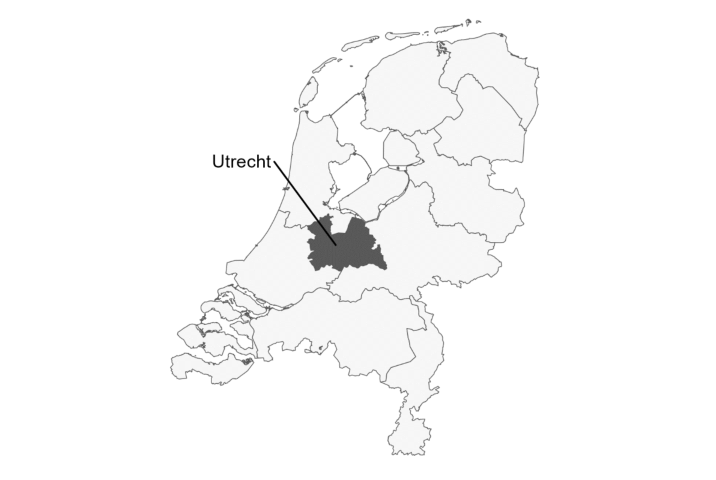

NOTE: figure/graphic rendered as an image from the PDF; its content is not machine-readable text. Caption (if any) follows as the next block.

items and quantities bought, prices paid, and whether the item was purchased on promotion). Our

household scanner panel data also contain information about shoppers’ home location (four-digit

zip code, municipality, and province).<sup>6</sup>

6 Food items represent the largest share of Lidl’s sales and are most prominently featured in Lidl’s store flyer. Nonfood items (e.g., clothing, hardware) are featured frequently too and represent 10% of Lidl’s sales (European Supermarket Magazine 2022). The GfK scanner panel focuses on households’ FMCG purchases however, prohibiting us from distinguishing these classes of products in our analyses.

Page 19

16

By putting a sticker on their mailbox, households can express their willingness to receive

flyers. The households that indicate their unwillingness to receive flyers are unaffected by Lidl’s

decision to cease delivery of its print store flyers. To obtain information on households’ use of

these mailbox stickers, we turned to two sources. First, in the first quarter of 2023, we conducted

a survey among all 10,000 GfK panel households, asking them whether they use a mailbox

sticker and when they started using it. The response rate was approximately 70%. We

complemented these responses with data from a previous survey, from early 2021, that asked the

same questions. Second, we obtained information from NOM, a Dutch media research

organization, which has surveyed a sample of panel households about their use of mailbox

stickers every year. We access these responses for 2017–2020 and use the data from 2020 to

complement the other survey data.<sup>7</sup> In total, we have information about households’ uses of

mailbox stickers for 75.5% of the sample.

We focus on households that visited a Lidl store at least once in 2021 or 2022 and that

receive store flyers.<sup>8</sup> Households are unlikely to change their shopping behaviors if a store they

have not visited in the past two years ceases delivering its print store flyer, and households that

do not receive print store flyers are not affected in the first place. After removing households that

were not consistently part of the panel, the focal sample consists of 2,772 households, all of

which visited Lidl in the two-year period preceding the treatment. Among these households, 172

(6.2%) live in Utrecht; the remaining 2,600 households from the 11 other provinces serve as

control households. Web Appendix B contrasts average household characteristics of treated and

7 Our data show that households are unlikely to change their choice of whether to receive store flyers over time. Among households for which we observe multiple data points, 94.3% retained their choice after a year. 8 We use 2021 and 2022 as the pretreatment period and focus on households that have visited a Lidl store at least once during this period to ensure a large enough sample. In two robustness checks, we shorten this period (once to 2022 and once to the last two quarters of 2022) and find qualitatively similar results.

Page 20

17

control households. There, we also show how the treated households represent the overall

customer base of Lidl well, reinforcing the validity of our results for a broader set of households.

#### *Measures and Model-Free Evidence*

To understand the impact of ceasing the delivery of store flyers, we look at households'

weekly shopping behavior along seven dimensions: (1) number of shopping trips, (2) total

grocery expenditures, (3) total number of units purchased, (4) total expenditures on promotion,

(5) total number of units purchased on promotion, (6) total expenditures not on promotion, and

(7) total number of units purchased not on promotion. We compute these measures for Lidl, and

then for all retailers except Lidl. Table 2 contains the descriptive statistics of the shopping

behavior for the focal treated and control households across all weeks; Figure 2 depicts model-

free evidence related to the household shopping behavior of treated and control households in

our sample, before and after Lidl retired its print store flyer.

The model-free evidence in Figure 2 indicates some notable differences in the weekly

shopping behavior measures, pre- and post-treatment, among the treated households. First, total

grocery expenditures across all retailers increased, but the number of units purchased decreased.

Notably, inflation was high during this period, with a cumulative inflation rate of more than

26%.<sup>9</sup> In response, households might have cut back on the number of items they purchased. In

addition, compared with a substantial part of the pre-treatment period, COVID-19 measures were

no longer in place in the post-treatment period, such that households could eat out again.<sup>10</sup>

Second, comparing the changes pre- and post-treatment across retailers against the

changes for Lidl, we find relatively larger changes for Lidl. For example, the total number of

9 As the control households come from the same country as the treated households, we implicitly account for any changes due to inflation in our analysis. 10 Note that COVID-19 measures were determined at the national level and similar across all Dutch provinces.

Page 21

18

**TABLE 2: DESCRIPTIVE STATISTICS, WEEKLY HOUSEHOLD SHOPPING**

#### **BEHAVIOR**

#### **A. LIDL**

|  | Treated (N =172) |  |  | Control(N =2600) , |  |
| --- | --- | --- | --- | --- | --- |
|  | Mean | SD | Min Max | Mean | SD Min Max |
| Numberofshoppingtrips Groceryexpenditure(in€s) Numberofunits | 55 . 1379 . 1132 . | 85 . 2500 . 2154 . | 0 7 0 24308 . 0 234 | 55 . 1487 . 1206 . | 81 0 7 . 2580 0 34750 . . 2145 0 266 . |
| Expenditureonpromotion(in€s) Numberofunits onpromotion Expenditurenotonpromotion(in€s) | 236 . 183 . 1143 . | 588 . 555 . 2140 . | 0 8961 . 0 109 0 22260 . | 228 . 170 . 1259 . | 549 0 16298 . . 468 0 165 . 2259 0 32270 . . |
| Numberofunits notonpromotion | 949 . | 1843 . | 0 216 | 1037 . | 1899 0 243 . |

NOTE: table converted from PDF layout to HTML text; cell boundaries are reconstructed. See PDF if exact alignment matters.

|  | Treated (N =172) |  |  | Control(N =2600) , |  |
| --- | --- | --- | --- | --- | --- |
|  | Mean | SD | Min Max | Mean | SD Min Max |
| Numberofshoppingtrips | 232 . | 190 . | 0 18 | 220 . | 170 0 17 . |
| Groceryexpenditure(in€s) Numberofunits Expenditureonpromotion(in€s) | 5448 . 3970 . 1377 . | 4368 . 3320 . 1639 . | 0 48948 . 0 288 0 17597 . | 5222 . 3856 . 1206 . | 4368 0 104935 . , . 3400 0 680 . 1541 0 27020 . . |
| Numberofunits onpromotion Expenditurenotonpromotion(in€s) Numberofunits notonpromotion | 919 . 4071 . 3051 . | 1225 . 3436 . 2696 . | 0 205 0 41433 . 0 272 | 820 . 4016 . 3036 . | 1199 0 317 . 3545 0 101441 . , . 2830 0 657 . |

NOTE: table converted from PDF layout to HTML text; cell boundaries are reconstructed. See PDF if exact alignment matters.

units purchased across all other retailers decreased by 5.5%, while the total number of units

purchased at Lidl decreased by 16.5% when it stopped delivering its print store flyers. This

decrease may be due, at least partly, to the 6.1% drop in the number of shopping trips to Lidl,

which stand in contrast with the number of trips to other retailers, which went up by 2.6%.

Third, zooming in on purchases on promotion versus not, the measures indicate a

relatively larger decrease for Lidl and purchases on promotion. For example, the total number of

units purchased on promotion decreased by 9.3% across all other retailers and by 30.9% at Lidl;

the total number of units purchased not on promotion decreased by 4.4% across all other retailers

and by 13.6% at Lidl. Households arguably could have changed their shopping habits in response

to other developments, such as changes in COVID-19 restrictions, but the data for the control

Page 22

19

**FIGURE 2: PERCENTAGE DIFFERENCES IN SHOPPING BEHAVIOR PRE- VS.**

#### **POST-TREATMENT, TREATED AND CONTROL HOUSEHOLDS**

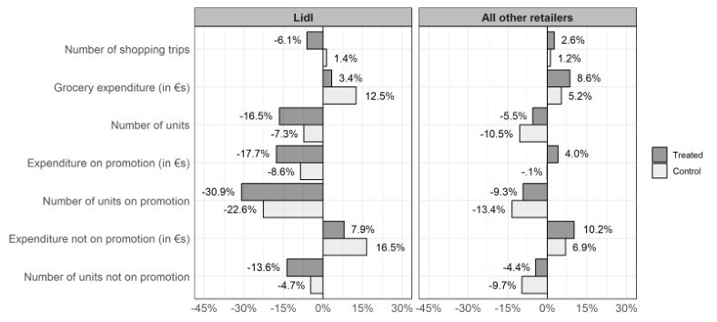

NOTE: figure/graphic rendered as an image from the PDF; its content is not machine-readable text. Caption (if any) follows as the next block.

households do not show a comparable loss for Lidl and win for other retailers. To assess these

differences formally, we present a model to compare the shopping behavior of treated

households relative to a set of control households that continued to receive Lidl’s store flyer in

the next section.

#### **METHOD**

The treatment is applied at the household level (regardless of which Lidl store they visit).

Thus, to analyze the impact of ceasing the delivery of store flyers, we compare treated

households’ shopping behavior with the shopping behavior of households from provinces in

Page 23

20

which the store flyer continued to be delivered in a difference-in-differences (DID) framework.<sup>11</sup>

A key identifying assumption of the DID framework is the parallel trends assumption. That is,

we require similar pretreatment evolution in shopping behavior (i.e., in all dependent variables)

among treated and control households. As importantly for this case, the treatment is allocated to

one province. Although Web Appendix A shows that the treated province of Utrecht does not

differ much from other Dutch provinces, and especially other urban provinces, households living

in the control provinces may still exhibit different shopping behavior trajectories over time (e.g.,

respond differently to inflationary shocks). Therefore, a model that weights the controls, rather

than applying a standard DID framework, is more appealing. Specifically, we use the synthetic

difference-in-differences (SDID) approach (Arkhangelsky et al. 2021), which reweights the

control households to make the time trend parallel (for similar approaches, see, e.g., Berman and

Israeli 2022; Guyt, van Lin, and Keller 2024; Li et al. 2022). In creating a synthetic control

group, we thus maximize the overlap in shopping behavior between households in the treated

province of Utrecht and households from other Dutch provinces.<sup>12</sup>

#### *Synthetic Difference-in-Differences*

The SDID approach leverages the advantages of synthetic control (SC), as introduced by

Abadie and Gardeazabal (2003), and DID, as used by Ashenfelter and Card (1985) and Bertrand,

Duflo, and Mullainathan (2004) for example. Similar to a SC approach (and unlike standard

11 The store flyer is distributed by a third party, i.e., not by stores itself. As such, households that live close to the border (and may visit stores outside of the Utrecht province) are treated equally as households living in the center of the Utrecht province (i.e., they no longer receive Lidl’s flyer). Similarly, control households that visit a store in Utrecht do not receive the treatment. Thus, cross-border shopping is not a concern in our setting. 12 As indicated in the “Setting and Data” section, Lidl choose Utrecht as a test market because of its degree of urbanization. As importantly, the key assumption of our SDID framework is parallel trends in terms of shopping behavior of individual households. As such, we create a synthetic group using households from all other Dutch provinces to maximize the similarity in the shopping trends between treated and control households. In a robustness check, we restrict the potential controls to households coming from two provinces (North and South Holland) with a similar degree of urbanization as Utrecht. We report on this robustness check in the “Results” section.

Page 24

21

DID), SDID uses pre-treatment data to construct a synthetic control group that better follows the

dependent variable’s trend of the treated households. But, unlike SC, SDID includes a

regularization parameter to improve the dispersion of the control unit weights when creating the

synthetic control group, so no control unit has a particularly strong influence, which prevents

overfitting. In turn, it is particularly suitable for a setting in which the number of controls is

relatively high (Abadie 2021; Li and Sonnier 2023). In addition to the control unit weights,

SDID (unlike SC) allows for time-varying weights; some pre-treatment periods may be more

relevant for constructing the synthetic control. The time weights remove bias and improve

precision. Finally, similar to a standard DID and unlike SC, SDID is invariant to baseline-level

differences in dependent variables and allows for valid, large panel inferences.

To assess the effect on grocery behavior Yit of household i in week t, we estimate:<sup>13</sup>

**equation / math rendering (image)**

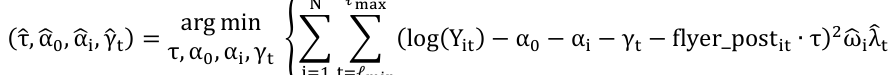

NOTE: contains mathematical notation; text above is the PDF text layer and symbols may be mis-extracted. Image shows the original.

**equation / math rendering (image)**

NOTE: contains mathematical notation; text above is the PDF text layer and symbols may be mis-extracted. Image shows the original.

**equation / math rendering (image)**

NOTE: contains mathematical notation; text above is the PDF text layer and symbols may be mis-extracted. Image shows the original.

**equation / math rendering (image)**

NOTE: contains mathematical notation; text above is the PDF text layer and symbols may be mis-extracted. Image shows the original.

**equation / math rendering (image)**

NOTE: contains mathematical notation; text above is the PDF text layer and symbols may be mis-extracted. Image shows the original.

**equation / math rendering (image)**

NOTE: contains mathematical notation; text above is the PDF text layer and symbols may be mis-extracted. Image shows the original.

where τ# is the estimated effect of ceasing the delivery of store flyers; α! is an intercept; α" and γ#

are household and week fixed effects, respectively; N is the set of treated and control

households; ℓ)"* denotes the start of the analysis window and ℓ)+, is the end of the window;

flyer_post"# is an indicator of whether household i resides in the treated province in which Lidl

ceased delivering store flyers during period t; and ω&" and λ<sup>A</sup># are unit weights for the control

households and time weights, respectively. The unit weights are chosen so the pre-treatment

period of the controls has a parallel trend to the treated households; the time weights are chosen

such that the pre- and post-treatment periods for the controls are similar (up to a constant). A

13 When taking the log of the dependent variables, we add a small constant (1). The results are substantively similar if we use an alternative constant (.1) before the log transformations, when the variables are expressed in eurocents (cf. euros), and when we use an arcsin transformation (cf. log transformation with an added constant).

Page 25

22

standard, two-way, fixed-effects DID approach does not include unit and time weights but

otherwise would be the same. In this sense, the SDID estimator provides a doubly weighted least

squares regression estimator of a standard DID model (for a more technical discussion, see

Arkhangelsky et al. 2021). As is common for SDID models, standard errors are computed using

the Jackknife procedure (Arkhangelsky et al. 2021). In each iteration, a (treated or control)

household is left out, such that the standard errors are clustered at the household level (Cameron

and Miller 2015).

#### *Estimation Sample (Treated and Control Households)*

The treatment group consists of all households that visited Lidl at least once in the pre-

treatment period, receive store flyers (see “Setting and Data” section), and reside in the Utrecht

province. Households in other provinces that meet the other criteria constitute the control

households.<sup>14</sup> In Web Appendix C, we provide the pre-treatment outcomes for the SDID control

households and the treated households; the trends in the pre-treatment outcomes are parallel.

There, we also provide the pre-treatment correlation between treated and control units. On

average, the outcomes of the SDID control are highly correlated with the outcomes of the treated

group (Lidl: .71; all other retailers: .84). The correlations for SDID are also higher than for the

unweighted raw cases (Lidl: .58; all other retailers: .76). Thus, the reweighted data better match

the pretreatment outcomes.<sup>15</sup>

14 We provide robustness checks that consider alternative definitions of the treated and control groups in the “Results” section. 15 We note that for certain outcomes, the correlation for the unweighted cases is already relatively high, such that the parallel trend requirement may already be satisfactorily addressed. In that case, a traditional DID model is unbiased and more efficient (see Li and Van den Bulte 2023 for an excellent discussion). Web Appendix D provides the results of a traditional (two-way fixed effects) DID model (with clustered standard errors at the household level) and shows the same pattern of results.

Page 26

23

#### **RESULTS**

Table 3 contains the SDID estimates for each dimension of grocery shopping behavior,

separately for Lidl and for all retailers but Lidl. In line with the model-free evidence, the results

show notable changes in household grocery shopping behavior. First, households decreased their

expenditures (e<sup>(-.080)</sup> – 1 = -7.7%) and the number of units purchased at Lidl (-6.1%) after it

ceased delivery of the printed store flyer. Zooming in on purchases on promotion versus not, we

also note that households decreased purchases on promotion (expenditures: -4.6%; number of

units purchased: -3.7%), as well as their purchases not on promotion (expenditures: -6.3%;

number of units purchased: not significant at any conventional level). These changes might be

attributed, at least partly, to the decrease in the number of shopping trips to Lidl (-2.0%). Among

the other retailers, the effect on the number of shopping trips is positive but not significant. At

the same time though, households increased their expenditures (6.2%) and number of units

purchased (6.2%) at these retailers. These increases result from an increase in purchases not on

promotion (expenditures: 6.6%; number of units purchased: 6.6%); the effect on purchases on

promotion at these other retailers is not significant. As explained before, many items featured in

Lidl’s store flyer can also be found at other retailers, and the results suggest that households

seem to replace purchases at Lidl, some of which they otherwise may have purchased on

promotion, with purchases at these other retailers that are not on promotion.

#### *When Households No Longer Receive a Retailer’s Store Flyer, Which Retailers Do They Turn*

#### *To?*

The reallocation of purchases to other retailers raises the question: Which retailers benefit

from Lidl’s decision to cease delivery of its print store flyer? The Dutch retail landscape consists

of several other (large) retailers, which can be classified as traditional or hard-discount retailers.

Page 27

24

**TABLE 3: SDID ESTIMATES WEEKLY SHOPPING BEHAVIOR AT LIDL AND ALL**

#### **OTHER RETAILERS**

|  |  | Lidl |  | AllOtherRetailers |  |  |
| --- | --- | --- | --- | --- | --- | --- |
|  | 𝛕" | SE | p | 𝛕" | SE | p |
| Log(Numberofshopping trips) | 020 -. | 009 . | 028 . | 013 . | 011 . | 258 . |
| Log(Grocery expenditure) Log(Number ofunits) Log(Expenditure onpromotion) | 080 -. 063 -. 047 -. | 037 . 033 . 018 . | 029 . 057 . 009 . | 060 . 060 . 037 . | 029 . 028 . 029 . | 038 . 033 . 203 . |
| Log(Number ofunits onpromotion) Log(Expenditure notonpromotion) Log(Number ofunits notonpromotion) | 038 -. 065 -. 046 -. | 015 . 036 . 033 . | 010 . 067 . 165 . | 027 . 064 . 064 . | 026 . 028 . 027 . | 283 . 024 . 019 . |

NOTE: table converted from PDF layout to HTML text; cell boundaries are reconstructed. See PDF if exact alignment matters.

Although all other retailers might benefit, the null effect on the number of shipping trips to other

retailers suggests that households mainly increased their purchases at retailers they already

visited before. In addition, Lidl is a hard-discount retailer; other retailers with the same format

arguably may benefit disproportionally from Lidl’s decision. To understand households’

purchase reallocations, we consider grocery shopping behavior at other retailers that households

(already) visit and at the other hard-discount retailer active in the Netherlands. In terms of other

retailers that households already visit, we focus on purchases at households’ primary retailer,

defined as the retailer with the largest expenditure share in the period before Lidl ceased delivery

of its print store flyer (excluding Lidl). Next, we reestimate our SDID model and include

measures of (weekly) shopping behavior at these subsets of retailers (i.e., one set of measures for

the primary retailer and one set for the other hard discounter). Table 4 presents the SDID

estimates for each dimension of grocery shopping behavior. The estimates show that the increase

in expenditures and number of units purchased (not on promotion) reflects additional shopping at

households’ primary retailer (7.5%-7.8%). For the other hard-discount retailer none of the

estimates reach significance at any conventional level, such that it does not seem to benefit from

Lidl’s decision. For the large majority of Lidl customers in our analysis, the other hard-discount

Page 28

25

retailer is not among their regularly visited retailers (for 77.3% of the households the other hard

discounter is not even among their top three retailers and for the others it is most often ranked as

third, after two other retailers). Instead of combining trips to two hard-discount retailers, most

Lidl customers thus combine trips to Lidl with traditional retailers (see also Vroegrijk,

Gijsbrechts, and Campo 2013, who show high complementarity between traditional and hard-

discount retailers and low complementarity among hard-discount retailers). In further

(unreported) robustness checks, we consider households’ secondary retailer and other individual

retailers (next to the other hard-discount retailer) but found no significant effects on household

shopping behavior. Thus, we conclude that when Lidl decided to cease delivery of its print store

flyer, households primarily reallocated their shopping to their primary retailer, that is, the one

they already visited regularly, but no other retailer benefited from Lidl’s decision.

**TABLE 4: SDID ESTIMATES WEEKLY SHOPPING BEHAVIOR AT HOUSEHOLDS’**

#### **PRIMARY AND THE OTHER HARD-DISCOUNT RETAILER**

|  | Households’primary | OtherHard -Discount |  |
| --- | --- | --- | --- |
|  | retailer(excl Lidl) . | Retailer |  |
|  | 𝛕" SE p | 𝛕" SE | p |
| Log(Numberofshoppingtrips) Log(Groceryexpenditure) | 015 011 165 . . . 072 040 075 . . . | 007 008 . . 040 032 . . | 343 . 216 . |
| Log(Numberofunits) Log(Expenditureonpromotion) Log(Numberofunits onpromotion) | 070 036 054 . . . 027 027 357 . . . 016 024 491 . . . | 045 030 . . 016 014 . . 011 012 . . | 141 . 258 . 369 . |
| Log(Expenditurenotonpromotion) Log(Numberofunits notonpromotion) | 075 038 047 . . . 072 034 033 . . . | 039 030 . . 044 028 . . | 196 . 120 . |

NOTE: table converted from PDF layout to HTML text; cell boundaries are reconstructed. See PDF if exact alignment matters.

#### *Does the Effect Differ for Households That Use the Retailer as Their Primary Versus Non-*

#### *Primary Shopping Destination?*

Households often engage in multiple-store shopping (Gijsbrechts, Campo, and Nisol

2008), and our analyses also suggest households visit Lidl alongside other retailers. In particular,

Page 29

26

households often buy the majority of their groceries at one retailer, but then combine their

shopping at this “primary” retailer with visits to other retailers. Households for which Lidl is not

the primary retailer may visit Lidl only after receiving the store flyer, because the flyer reminds

of the retailer or promises an attractive promotion. Households for which Lidl is the primary

retailer instead may pay less attention to the store flyer, because they visit the retailer regardless,

so the negative effect of eliminating the flyer on their shopping behavior might be less severe.

As before, we define the primary retailer as the one with the largest expenditure share in

the period before Lidl ceased delivery of its print store flyer. Lidl is the primary retailer for about

25% of the households in our focal sample; other households visit Lidl too but buy the majority

of their groceries elsewhere. We estimate the SDID model separately for these two subgroups,<sup>16</sup>

and the results in Table 5 reveals some striking differences between them. For households for

which Lidl is not the primary retailer, we find negative effects on all dimensions of shopping

behavior. For households for which Lidl is the primary retailer, the effects are substantially

smaller, and none of them are significant at any conventional level.<sup>17</sup>

#### *Can Promoting Digital Store Flyers Prevent Changes in Shopping Behavior?*

Lidl ceased delivery of its print store flyer, but its store flyer is also available digitally.

Households that download Lidl’s app can browse the store flyer digitally; they also can visit

Lidl’s website or subscribe to receive its digital newsletter. For households that select these

16 There are several ways to compute subgroup effects with the SDID model (Berman and Israeli 2022). Because our primary interest is to understand the effect for different subgroups, we use control households from the same subgroup (i.e., for which Lidl is the primary retailer or not). 17 The number of treated (and control) households in the analysis for households for which Lidl is the primary retailer is lower than that of the analysis for households for which Lidl is not the primary retailer, which could lead to differences in the effects between these two subgroups. We reconducted the analysis for households for which Lidl is the primary retailer but inflated the sample to equal the size of the non-primary retailer sample by sampling from the original sample with replacement. This technique is akin to random oversampling for imbalanced data (Chawla 2010). Across 100 random samples, only 11.1% of the estimates (number of dependent variables ´ number of random samples) are significant at *p* < .10. The difference in sample size thus does not appear to drive the differences in effects.

Page 30

27

**TABLE 5: SDID ESTIMATES: LIDL AS THE PRIMARY RETAILER VS. NON-**

#### **PRIMARY RETAILER**

|  | HouseholdsforwhichLidlIsNot |  | HouseholdsforwhichLidlIsthe |  |  |
| --- | --- | --- | --- | --- | --- |
|  |  | thePrimaryRetailer |  | Primary | Retailer |
|  |  | Lidl AllOther |  | Lidl | AllOther |
|  |  | Retailers |  |  | Retailers |
|  | 𝛕" | SE p 𝛕" SE p | 𝛕" | SE p | 𝛕" SE p |
| Log(Numberofshopping | 023 -. | 009 012 026 013 049 . . . . . | 000 -. | 027 999 . . | 026 021 215 -. . . |
| trips) Log(Groceryexpenditure) Log(Numberofunits) | 088 -. 074 -. | 038 021 091 031 003 . . . . . 034 029 097 031 002 . . . . . | 053 -. 017 -. | 105 615 . . 093 858 . . | 033 070 634 -. . . 055 063 386 -. . . |
| Log(Expenditureon | 057 -. | 017 001 056 034 099 . . . . . | 027 -. | 059 650 . . | 024 053 644 -. . . |
| promotion) Log(Numberofunits on | 043 -. | 013 001 046 030 128 . . . . . | 022 -. | 050 656 . . | 016 045 728 -. . . |
| promotion) Log(Expenditurenoton | 072 -. | 037 050 091 030 003 . . . . . | 042 -. | 104 683 . . | 035 068 606 -. . . |
| promotion) Log(Numberofunits not onpromotion) | 058 -. | 034 084 096 030 002 . . . . . | 003 -. | 094 976 . . | 047 060 438 -. . . |

NOTE: table converted from PDF layout to HTML text; cell boundaries are reconstructed. See PDF if exact alignment matters.

Notes: Total number of observations in the analysis for which Lidl is not (is) the primary retailer (no. of households ´ 130 weeks): 269,750 (90,610).

options after Lidl ceased delivery of its print store flyer, little may change, such that the negative

effect might be less severe or even nonexistent. To test this prediction, we collected information

about households’ usage of digital alternatives. In the survey conducted in the first quarter of

2023 (see the “Setting and Data” section), we additionally asked all 10,000 GfK panel

households about their usage of digital alternatives to Lidl’s print store flyer. That is, we asked

households whether they ever check Lidl’s store flyer digitally and, if so, how long they had

been doing so and how often they do so. The response rate was approximately 70%.<sup>18</sup>

18 We complemented these data with data from GfK’s annual household survey, which includes a question about whether households have installed the Lidl app (the primary digital alternative) and how often they use it. For households that did not respond to our survey, we used their response to the 2023 GfK survey.

Page 31

28

Figure 3 presents the descriptive statistics separately for treated households (residing in

Utrecht) and control households (residing in other provinces) in the sample.<sup>19</sup> As it shows, most

households check Lidl’s store flyer digitally; we find no difference between treated and control

households. However, a substantial portion of the treated households only recently adopted the

digital store flyer; 35.5% (12.1% + 23.4%) of them started checking the digital store flyer only in

the past three months (vs. 13.9% [5.0% + 8.9%] of control households). Although some treated

households adopted digital flyers proactively in the past, many only started doing so when they

no longer received Lidl’s print store flyer, and Lidl began promoting the digital alternative.<sup>20</sup> We

find no differences in the frequency of checking Lidl’s digital store flyer between treated and

control households.

With an exploratory analysis, we also compare the effect of ceasing the delivery across

households according to their adoption of Lidl’s digital store flyer, to understand if promoting

the digital store flyer might help mitigate the negative effects on shopping behavior.<sup>21</sup> Based on

the results of the survey, we compare three groups. The first group of households has never

adopted the digital store flyer, so they stop receiving Lidl’s offers. One group of adopters

embraced the digital flyer long time ago; the other group only started doing so when they no

longer received Lidl’s print store flyer. The former group likely feels comfortable with digital

store flyers already, but the latter might be less engaged, and they could have adopted the digital

flyer only because they no longer receive the print version. This difference in motivation raises

questions as to whether promoting the digital store flyer is an effective strategy for retaining

19 We compute the descriptive statistics for households in our focal sample. The results remain similar if we include all households that responded to the survey. 20 The survey ran in the first quarter of 2023, and Lidl had ceased delivery of its print store flyer at the start of 2023. 21 Households self-select into these groups, so our analysis is correlational rather than causal. We return to this issue in the limitations section and suggest opportunities for retailer experimentation to obtain causal estimates.

Page 32

29

**FIGURE 3: DESCRIPTIVE STATISTICS OF HOUSEHOLDS’ USAGE OF LIDL’S**

#### **DIGITAL STORE FLYER AMONG TREATED AND CONTROL HOUSEHOLDS**

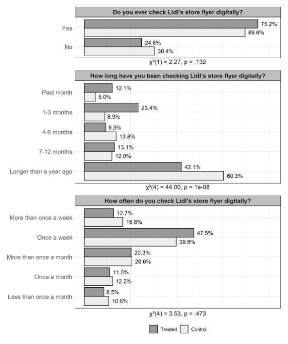

NOTE: figure/graphic rendered as an image from the PDF; its content is not machine-readable text. Caption (if any) follows as the next block.

Notes: The descriptive statistics for the first and third questions are based on a survey that we conducted in early 2023, complemented by 2023 data from GfK’s annual survey. That survey does not ask how long households have been checking Lidl’s store flyer digitally, so the descriptive statistics for the second question is based solely on our survey. Number of treated (control) households for question 1: 157 (2,400); question 2: 107 (1,452); question 3: 118 (1,671). The percentages do not add to 100% due to rounding.

households. We compare all three groups (households that adopted Lidl’s digital store flyer more

than three months ago, adopted it in the past three months, and did not adopt) and estimate the

Page 33

30

SDID model separately for them.<sup>22</sup> Table 6 contains the estimates for each dimension of grocery

shopping behavior, for Lidl (Panel A) and for all retailers other than Lidl (Panel B). For Lidl, no

significant effects emerge for households that adopted its digital flyer more than three months

ago or, interestingly, for households that did not adopt Lidl’s digital flyer at all. The former are

likely comfortable with digital flyers already; the latter might not have used Lidl’s store flyer

much anyway. For households that adopted Lidl’s digital flyer in the past three months, however,

we find negative effects on all dimensions of shopping behavior. They adopted digital flyers

around the time they stopped receiving Lidl’s print store flyer, and their behaviors imply they are

not as engaged with digital flyers as earlier adopters, such that the switch leads them to cut back

or forgo shopping at Lidl.

Turning to the effects on purchases at other retailers, we similarly find that the change in

behavior of households that recently adopted the digital flyer differs from other households (that

adopted earlier or not at all). The differential change suggests different underlying motives (e.g.,

exploration, replacement of the print flyer, or complementary to the print flyer). Notably, for

households that adopted Lidl’s digital flyer in the past three months, we do not find any evidence

that they replace their purchases at Lidl with purchases from other retailers. In this group, Lidl’s

store flyer seems to have prompted additional shopping and purchases of items that they

otherwise would not have purchased (in line with a promotional effect on primary demand;

Anderson and Fox 2019).

Overall, the results of this analysis offer a nuanced view of the effect of digital flyers.

The digital store flyer provides the same information as the printed store flyer and can

theoretically fully replace it. But a physical version of the store flyer still might attract the

22 As controls, we use households from the same subgroup (i.e., adopted around the same time or not).

Page 34

31

**TABLE 6: SDID ESTIMATES BY HOUSEHOLDS’ ADOPTION OF DIGITAL FLYERS**

#### **A. LIDL**

|  | AdoptedLidl’sDigital |  | AdoptedLidl’sDigital |  |  | DidNotAdoptLidl’s |  |
| --- | --- | --- | --- | --- | --- | --- | --- |
|  | FlyerMorethanThree |  | FlyerinthePastThree |  |  | DigitalFlyer |  |
|  | MonthsAgo |  |  | Months |  |  |  |
|  | 𝛕" SE | p | 𝛕" | SE | p | 𝛕" SE | p |
| Log(Numberofshopping | 020 015 -. . | 168 . | 055 -. | 024 . | 025 . | 018 016 -. . | 271 . |
| trips) Log(Groceryexpenditure) Log(Numberofunits) Log(Expenditureon | 047 060 -. . 035 055 -. . 041 030 -. . | 434 . 518 . 161 . | 276 -. 251 -. 149 -. | 094 . 085 . 047 . | 003 . 003 . 002 . | 075 062 -. . 075 058 -. . 015 023 -. . | 188 . 198 . 403 . |
| promotion) Log(Numberofunits on | 039 026 -. . | 136 . | 073 -. | 033 . | 027 . | 030 021 -. . | 143 . |
| promotion) Log(Expenditurenoton | 042 059 -. . | 481 . | 262 -. | 090 . | 004 . | 054 059 -. . | 318 . |
| promotion) Log(Numberofunits not onpromotion) | 024 054 -. . | 658 . | 236 -. | 082 . | 004 . | 051 056 -. . | 355 . |
|  | B ALLOTHER . |  | RETAILERS |  |  |  |  |

NOTE: table converted from PDF layout to HTML text; cell boundaries are reconstructed. See PDF if exact alignment matters.

|  | AdoptedLidl’sDigital |  | AdoptedLidl’sDigital |  |  | DidNotAdoptLidl’s |  |
| --- | --- | --- | --- | --- | --- | --- | --- |
|  | FlyerMorethanThree |  | FlyerinthePastThree |  |  | DigitalFlyer |  |
|  | MonthsAgo |  |  | Months |  |  |  |
|  | 𝛕" SE | p | 𝛕" | SE | p | 𝛕" SE | p |
| Log(Numberofshopping | 014 016 . . | 379 . | 007 -. | 031 . | 825 . | 027 024 . . | 272 . |
| trips) Log(Groceryexpenditure) Log(Numberofunits) Log(Expenditureon | 096 048 . . 100 047 . . 039 048 . . | 046 . 032 . 418 . | 016 -. 010 -. 039 . | 052 . 055 . 066 . | 760 . 855 . 560 . | 089 050 . . 099 048 . . 040 057 . . | 083 . 039 . 432 . |
| promotion) Log(Numberofunits on | 025 041 . . | 548 . | 010 -. | 058 . | 858 . | 049 056 . . | 388 . |
| promotion) Log(Expenditurenoton | 095 045 . . | 033 . | 009 . | 053 . | 865 . | 082 054 . . | 141 . |
| promotion) Log(Numberofunits not onpromotion) | 107 043 . . | 013 . | 010 . | 056 . | 857 . | 097 050 . . | 053 . |

NOTE: table converted from PDF layout to HTML text; cell boundaries are reconstructed. See PDF if exact alignment matters.

Notes: Total number of observations of households that adopted Lidl’s digital flyer longer than three months ago (no. of households ´ 130 weeks): 171,600; that adopted Lidl’s digital flyer in the last three months: 31,070; that did not adopt Lidl’s digital store flyer: 99,840.

attention of households that adopt digital flyers. As importantly, for households only adopting

digital flyers around the time that delivery of the print store flyer stopped, we identify a negative

effect on shopping behavior, suggesting that pushing households toward digital alternatives

Page 35

32

could have adverse effects. We revisit households’ motivations to adopt digital store flyers in the

“Discussion” section.

#### *Robustness Checks and Placebo Tests*

We used the SDID model to create a synthetic control group to maximize the overlap in

shopping behavior with households in the treated province of Utrecht. Although Arkhangelsky et

al. (2021) show that estimating these weights comes at little cost of additional variance, a DID

model is unbiased and more efficient if the parallel trends assumption holds for the unweighted

series. Thus, we compare our results to those of the traditional (two-way fixed effects) DID

model (with clustered standard errors at the household level). The results in Web Appendix D

show a robust pattern.

Next, we test the robustness of our results to alternative definitions of the sample and

control group and to alternative time windows. First, instead of comparing households in the

Utrecht province that receive store flyers with households in other provinces that receive store

flyers, we compare households in Utrecht that receive store flyers with households also in

Utrecht that do not receive store flyers (i.e., did not receive Lidl’s or any other chain’s store flyer

to begin with; see Table 7, “RC1”, for a schematic overview). Second, given Lidl’s decision to

pick Utrecht as a test market because of its degree of urbanization, we restricted the potential

pool of control households to come from two provinces (North and South Holland) with a similar

degree of urbanization as Utrecht (Table 7, “RC2”). Third, some municipalities in Utrecht are

“opt-in municipalities” in which households only receive store flyers if they opt in (compared to

“opt-out municipalities” in which all households receive store flyers unless they opt out). The set

of treated households may, therefore, contain some households that are more likely to be print

store flyer “enthusiasts,” for which the effects may be larger. Instead of selecting all households

Page 36

33

that receive store flyers for our sample, we therefore only select households living in opt-out

municipalities that receive store flyers (both in Utrecht and in the control provinces; see Table 7,

“RC3”). Fourth, we drop the four weeks preceding the point in time when Lidl ceased delivery of

its store flyer, to account for any changes prior to the official implementation date. Similarly, we

drop the four weeks following the implementation to allow for a “dust-settling” period (Keller,

Guyt, and Grewal 2024). The results of these five robustness checks (i.e., two alternative control

groups, opt-out municipalities only, dropping four weeks preceding the implementation,

dropping four weeks after the implementation), as detailed in Figure WA2 in Web Appendix E,

are similar to the results of our main analysis. We thus corroborate the conclusion that

households reduce their shopping at Lidl, and increase their shopping at other retailers,

particularly for non-promoted items.

Lidl also might have increased its advertising spending in Utrecht. As we noted

previously (see footnote 5), we consider local advertising adaptations unlikely, considering the

national character of retail advertising in the Netherlands. Still, any increase in advertising

spending could affect households in the Utrecht province that do not receive store flyers at all

(e.g., have opted out). To test for this possibility, we compare households residing in Utrecht that

do not receive store flyers with households residing in other provinces that do not receive store

flyers (Table 7, “Placebo”). The results (Figure WA3, Web Appendix E) indicate no differences

in household grocery shopping behavior, affirming that local advertising changes are unlikely.<sup>23</sup>

23 Even if a retailer locally increased its advertising spending, it would mitigate any potential changes in household grocery shopping behavior, such that our estimates would serve as a lower bound of the effect.

Page 37

34

**TABLE 7: TREATED AND CONTROL HOUSEHOLDS**

| Utrecht province | Opt -out municipalities in Utrecht | Otherprovinces | Opt -out municipalities in other | Otherurban provinces |
| --- | --- | --- | --- | --- |
|  | province |  | provinces |  |
| Flyers Flyers Analysis =Yes1 =No1 | Flyers Flyers =Yes1 =No1 | Flyers Flyers =Yes1 =No1 | Flyers Flyers =Yes1 =No1 | Flyers Flyers =Yes1 =No1 |
| Main Treated |  | Control |  |  |
| RC1 Treated Control RC2 Treated RC3 Placebo “Treated” | Treated | “Control” | Control | Control |

NOTE: table converted from PDF layout to HTML text; cell boundaries are reconstructed. See PDF if exact alignment matters.

#### **DISCUSSION**

#### *Summary*

Many retailers still distribute print store flyers to households to communicate about the

availability, price, and promotions of products in their assortments. Yet they also recognize that

digital flyers would cost substantially less, could provide the same information to digitally savvy

consumers, and could help them reduce their environmental footprint. Considering such potential

and the growing trend of eliminating print store flyers by global retailers, we study the effects of

the voluntary retirement of print store flyers on household shopping behavior.

*How do households change their behavior?* Industry reports suggest based on before-

after comparisons that retailers may lose foot traffic when they retire store flyers: “most retailers

that stopped using print flyers […] saw a reduction in customer visits relative to competitors who

maintained the print flyer.” (Retail Brew 2022). Our results, based on a synthetic difference-in-

differences model, confirm these predictions. Households engage in fewer shopping trips to the

retailer that eliminates its print store flyer and also spend less. Zooming in, our results add to

these insights by showing how households avail themselves of fewer promotions when they no

longer hear about them through the print store flyer, but also how they cut back on non-

promotional purchases.

*Where do households shop instead?* Households shift their purchases to other retailers,

but in our study context, the results indicate that no one particular retailer benefited. Households

often visit multiple retailers but also have a “primary” retailer, and they tend to reallocate their

shopping to this primary retailer they were already visiting. If the retailer that stops sending store

flyers represents their primary retailer, households do not change their shopping behavior.

Instead, they visit this retailer regardless, whereas others appear to visit it mainly after receiving

the store flyer, which reminds them of its presence or attracts them with a good promotion.

*Can promoting digital store flyers prevent changes in shopping behavior?* Although

many households adopt the digital flyer following the print flyer’s retirement, we find no

evidence that promoting this alternative source of information can offset the negative effect. The

digital flyer provides the same information as the print store flyer, but households that adopt the

digital flyer around the time the print flyer ceases to be distributed still turn away from the

retailer. Overall, retiring the store flyer can backfire for retailers, and offering a digital flyer does

not seem to provide an effective replacement for households that had not embraced this digital

option previously.

#### *Academic and Managerial Contributions*

Our study makes several contributions to retailing literature. Responsible retailing

research pertains to both voluntary initiatives and mandatory regulations linked to societal issues.

Previous research indicates that institutional bans on unsolicited store flyers (i.e., opt-in default)

can substantially reduce environmental waste, without substantially changing grocery shopping

behavior (Guyt, van Lin, and Keller 2024). We take a novel perspective and investigate a

voluntary change in a retailer’s communication strategy. In this case, retiring the store flyer

leaves some households that prefer to receive the print flyer (and would opt in, in response to the

regulatory mandate) without their preferred form of communication. Moreover, compared to an

institutional ban, the competition remains to distribute their store flyers. This result in turn

contributes to literature on store flyers and promotions too. A large body of literature has

demonstrated the sales effects of featuring products in store flyers (e.g., Guyt and Gijsbrechts

2018; van Lin and Gijsbrechts 2016), but we also note arguments that only a limited segment of

households uses store flyers to drive their store choice (Srinivasan and Bodapati 2006), as well as

indications that store flyers have a limited role in the conversion funnel (Seiler and Yao 2017).

This study is the first to consider a situation in which a retailer stops distributing print flyers

altogether. Even though not all households use store flyers, or use it to the same degree, retailers

cannot retire the print store flyer and hope to avoid any adverse effects.

It may seem obvious that retiring any communication channel would have an impact, but

the real-world practices of various retailers (e.g., Giant Eagle, Kroger, Coles, REWE) imply that

they thought they could eliminate their print store flyers without much issue. Managerially, our

findings reveal that the print store flyer is still integral to retailers’ operations, even in a digital

world. While the digital flyer provides the same information and already has a significant user

base, our results show that its effectiveness depends critically on households’ motivation to adopt

it. If they do so only because they no longer receive the print store flyer, they are likely to reduce

their spending with the retailer. Households that proactively adopt the digital flyer, while the

print version was still available, instead appear to feel more comfortable with the digital version,

and they do not adjust their spending. Some households may simply prefer to read the print

version and pushing them to adopt the digital flyer can backfire. For the same reason, it is

unlikely that with longer experience, these households would eventually fully adopt the digital

flyer (and that the outcome is just a short-term outcome). Industry surveys from the United States

and the Netherlands add some relevant insights to this discussion, by suggesting that households

might not engage as much with digital flyers, and many households enjoy perusing the print

flyers that appear in their mailbox (Progressive Grocer 2024b; Stantec 2024). Anecdotal

evidence also suggests that print flyers remain relevant for many retailers. Canadian retailer

Loblaw discontinued its print flyer in 2020, but, like Lidl in the Netherlands, reintroduced it

later, after a reportedly 2% drop in its share of consumers’ shopping trips (Retail Brew 2022). In

the US, Giant Eagle discontinued its print store flyer in 2023 and reversed course three months

later to meet “high demand” (Supermarket News 2023). Similarly, Aldi discontinued its store

flyer in one region of Germany but reversed course four months later (Lebensmittelzeitung

2024).

#### *Economic Impacts of Retiring the Print Store Flyer*

Printing and distributing store flyers might not seem very costly, but it is an untargeted

medium, such that some of these costs offer no returns (i.e., when print flyers reach households

that do not use them).<sup>24</sup> From an economic perspective, distributing print store flyers is only

profitable if the expected profit is greater than the cost.<sup>25</sup> Therefore, we perform policy

simulations for retailers, using our estimates and numbers published by the industry (i.e., average

profit margin and the cost of printing and distributing print flyers). The Appendix details the

calculations. The results in Figure 4 offer a nuanced picture. At the industry average net profit

24 Ideally, such a policy would be at the household level. While theoretically possible, it is logistically infeasible, due to the nature of the delivery. We return to this point in the “Limitations and Further research” section. 25 Digital store flyers also come at a cost. For example, the costs to develop and maintain an app can be substantial. Because most retailers already provide digital flyers though, it does not change the outcome of this analysis, and we do not consider those (mostly upfront) costs here.

margin (3%–4%; McKinsey 2023a; 2023b) and with a typical cost of store flyers (2 cents), the

effect of retiring the print store flyer is negative, such that retailers may find it beneficial to

continue to distribute print store flyers. If the cost of distributing the store flyers is higher though,

and the profit margin is low, the profit does not outweigh the costs, so the retailer could

eliminate the printed store flyers with little harm. Ultimately, our results clarify that retiring print

store flyers might have little economic impact in some cases, but they still provide value for the

average retailer.

**FIGURE 4: CHANGE IN PROFITS AFTER RETIRING THE PRINT STORE FLYER**

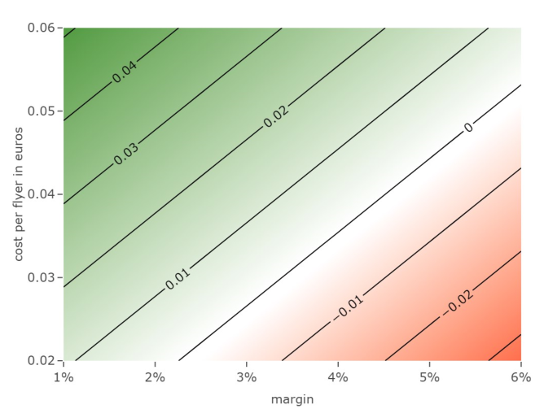

NOTE: figure/graphic rendered as an image from the PDF; its content is not machine-readable text. Caption (if any) follows as the next block.

Notes: The numbers on the lines indicate the change in profit (in Euros) due to retiring the print store flyer per household, per week. The green (red) area refers to scenarios in which retiring the store flyer positively (negatively) affects the retailer.

It is worth noting, though, that costs are not the only consideration for retailers in

deciding about the future of their store flyer distribution. The production and transportation of

store flyers is environmentally wasteful, and retailers may decide to eliminate the print version to

live up to their environmental goals, even if doing so means they lose some business. Similar to

the focal retailer Lidl that we study, the German retailer REWE cites environmental savings as

one of the key reasons it chose to stop distributing its print flyer (Lebensmittelzeitung 2022).

Policy makers likely welcome such voluntary initiatives and might look for ways to encourage

other retailers to take similar actions, such as by offering tax breaks to retailers that can

effectively reduce their environmental impact.

#### *Generalizability of the Results*

Lidl is the sixth largest retailer in the world in terms of revenue (International

Supermarket News 2024) and is a hard-discount retailer. By now, the hard-discount channel

represents a sizeable part of the market in many parts of the world (Steenkamp and Sloot 2018)

and is growing rapidly in the US as well (Progressive Grocer 2024a); but it is relevant to also

consider how our results may generalize to other types of retailers. Consumers often visit hard

discounters next to other retailers and other types of retailers might be more likely to be the

primary retailer for a household (Steenkamp and Sloot 2018). In our data, the ratio of households

for which Lidl is the primary versus secondary retailer is .93, whereas the ratio for the top three

traditional retailers based on market share equals 1.22. This suggests that Lidl is indeed more

often a secondary retailer but the difference is rather limited. Moreover, traditional retailers,

while often being households’ primary retailer, also see many households visit them next to their

primary retailer, as evidenced by a ratio close to 1. Although our results show that households

visit their primary retailer regardless of receiving the store flyer, the business these other

customers contribute is not negligible. Crucially, those other customers might visit the retailer

only after receiving the store flyer, when they are reminded of the retailer, or see an attractive

promotion in its store flyer. As importantly, the share of purchases on promotion is typically

higher for traditional retailers than for hard discounters (in our data: 24.1% for the top three

traditional retailers vs. 14.7% for Lidl), implying that a large part of their purchases is at risk if

consumers no longer hear about these promotions. Thus, the magnitude of the effect may vary,

but eliminating the print store flyer seems likely to have adverse impacts on the business,

regardless of the type of retailer.

Our results also indicate that apps or other digital alternatives cannot safeguard retailers

against the negative effects as households that adopted a digital alternative around the time the

flyer was ceased still reduce their shopping at the retailer. Yet, this segment may be particular to

hard-discount retailers. Further analysis of the demographics of households that adopt digital

flyers around the time the flyer was ceased suggests that these households tend to be somewhat

older and belong to a somewhat lower social class. However, these households are also among

the regular customers of traditional retailers, such that we believe that forcing households

towards digital alternatives can backfire for these retailers, too.

#### *Limitations and Further Research*

We close by noting the limitations, which provide intriguing avenues for further research.

First, we explore whether digital flyers might replace the print flyer, by comparing households

that recently adopted digital flyers against households that did so previously and those that did

not adopt them. The insights into the distinct behaviors of these groups are relevant, but they

cannot establish the causal effects of digital flyer adoption, because households self-select into

their adoption choice. If retailers aim to generalize beyond these specific subgroups to

understand the potential replacement value of digital flyers, they might try experimentally

incentivizing households to do so, rather than relying on households to self-select into the

different groups.

Second, our optimal policy analysis refers to the market level, which is the level at which

the retailer instituted the change. Changes also could take place at lower levels. If retailers

understand which subgroups, or even individual households, are more versus less affected, they

could attempt to microtarget (as in, e.g., Danaher 2023). We note two potential options for

improving our understanding of heterogeneous uses of print store flyers: (1) retailers that operate

loyalty programs that log all behavior could experimentally cease delivery to selected households

and monitor their shopping behavior or (2) retailers can experimentally cease distribution in

specific local areas (e.g., 3-digit zip code) to determine if certain demographic areas are more

prone to using print store flyers. Although both efforts would be time-consuming and could risk

consumer reactance to being part of an experiment, they also would provide retailers with clear

evidence regarding a promising opportunity to save costs and do good for the environment

without losing business among households that use their flyers.

Third, store flyers generate income by affecting shopping behavior, but retailers also

often receive payments from manufacturers to feature the manufacturers’ products in their flyers

(“cooperative advertising”; CSPI 2016). Because not everyone embraces digital flyers, and

households may be less engaged with them, manufacturers might demand to renegotiate these

costs. The secrecy surrounding such payments makes it difficult to incorporate them in our

calculations, but in informal discussions with a former brand manager, we learned that when one

retailer retired its print flyer, the payments did not change. If manufacturers can successfully

renegotiate these costs though, it would provide another incentive for retailers to keep the print

store flyer. We leave it to further research to explore the influence of manufacturer payments on

retailers’ store flyer decisions.

Fourth, we study one retailer’s voluntary decision to retire its store flyer. Other retailers

did not follow suit, but in other or future cases all retailers may stop distributing their store flyer.

It is unclear how such a situation would play out. On the one hand, one may argue that such a

case retains the status quo. On the other hand, some retailers are more often secondary retailers

for consumers (who they may only visit after receiving their store flyer), and they may also stand

to lose if other retailers follow and retire their store flyer, too. In addition, promotions are

important to many retailers for reasons other than attracting consumers to their stores, and

consumers may not know of these promotions even if they visit the retailer, without seeing them

in the flyer; future research could analyze these cases when they happen.

We hope the findings of this study prove useful in contexts where well-established

marketing tools, such as print store flyers, are under increased scrutiny. We also hope it sparks

more interest in this important and growing field.

#### **REFERENCES**

Abadie, Alberto (2021), “Using Synthetic Controls: Feasibility, Data Requirements, and

Methodological Aspects,” *Journal of Economic Literature*, 59 (2), 391-425. Abadie, Alberto, and Javier Gardeazabal (2003), “The Economic Costs of Conflict: A Case

Study of the Basque Country,” *American Economic Review*, 93 (1), 113-132. Adalja, Aaron, Jūra Liaukonytė, Emily Wang, and Xinrong Zhu (2023), “GMO and Non-GMO

Labeling Effects: Evidence from a Quasi-Natural Experiment,” *Marketing Science*, 42 (2), 233-250. Adformatie (2020, November 11), “De folder is onmisbaar: zelfs de Tesla-rijder 38eft geen nee-

sticker [The Store Circular Is Indispensable: Even a Tesla Driver Doesn’t Have a “No” Sticker],” available at https://www.adformatie.nl/gedragsverandering/de-folder-onmisbaar. Ailawadi, Kusum L., Jonathan P. Beauchamp, Naveen Donthu, Dinesh K. Gauri, and Venkatesh

Shankar (2009), “Communication and Promotion Decisions in Retailing: A Review and Directions for Future Research,” *Journal of Retailing*, 85 (1), 42-55. Alé-Chilet, Jorge, and Sarah Moshary (2022), “Beyond Consumer Switching: Supply Responses

to Food Packaging and Advertising Regulations,” *Marketing Science*, 41 (2), 243-270. Anderson, Eric T., and Edward J. Fox (2019), “How Price Promotions Work: A Review of

Practice and Theory,” in *Handbook of Economics and Marketing*, Jean-Pierre Dubé and Peter E. Rossi, Eds., Amsterdam: North-Holland, pp. 497-552. Arkhangelsky, Dmitry, Susan Athey, David A. Hirshberg, Guido W. Imbens, and Stefan Wager

(2021), "Synthetic Difference-in-Differences," *American Economic* Review, 111 (12), 4088- 4118. Ashenfelter, Orley, and David Card (1985), “Using the Longitudinal Structure of Earnings to

Estimate the Effect of Training Programs,” *Review of Economics and Statistics*, 67 (4), 648- 660. Berman, Ron, and Ayelet Israeli (2022), “The Value of Descriptive Analytics: Evidence from

Online Retailers,” *Marketing Science*, 41 (6), 1074-1096. Bertrand, Marianne, Esther Duflo, and Sendhil Mullainathan (2004), “How Much Should We

Trust Differences-In-Differences Estimates?” *The Quarterly Journal of Economics*, 119 (1), 249-275. Cameron, A. Colin, and Douglas L. Miller (2015), “A Practitioner’s Guide to Cluster-Robust

Inference,” *Journal of Human Resources*, 50 (2), 317-372. Chawla, Nitesh V. (2010), “Data Mining for Imbalanced Datasets: An Overview,” *Data Mining*

*and Knowledge Discovery Handbook* (Oded Maimon and Lior Rokach, eds.), Boston, MA: Springer. Ching, Andrew T., and Daniel Goetz (2024), “Consumption Responses to an Unpopular Policy:

Evidence from a Short-Lived Soda Tax,” *Marketing Science*, 43 (6), 1204-1255. CNN (2023, May 2), “Kroger will end its weekly grocery specials in newspapers,” available at

https://edition.cnn.com/2023/05/02/business/groceries-sales-kroger-newspapers/index.html.

CSPI (2016), “Rigged - Supermarket Shelves for Sale,” Washington DC: Center for Science in the

Public Interest. Danahar, Peter (2023), “Optimal Microtargeting of Advertising,” *Journal of Marketing Research*,

60 (3), 564-584. Dhar, Tirtha, and Kathy Baylis (2011), “Fast-Food Consumption and the Ban on Advertising

Targeting Children: The Quebec Experience,” *Journal of Marketing Research*, 48 (5), 799- 813. Distrifood (2022, December 9), “Lidl stopt met verspreiden folders in provincie Utrecht [Lidl stops

distributing its store flyer in the province of Utrecht],” available at https://www.distrifood.nl/162890/lidl-stopt-met-verspreiden-folders-in-provincie-utrecht. Distrifood (2023a, January 18), “NielsenIQ marktaandelen 2022: Marktaandeel Jumbo en Lidl

daalt [NielsenIQ market shares 2022: Market share Jumbo and Lidl drops],” available at https://www.distrifood.nl/163676/nielens-marktaandeel-supermarkten-jumbo-en-lidl-dalen. Distrifood (2023b, November 20), “Stoppen weekfolder bespaart Plus-ondernemers duizenden

euro’s [Discontinuing the weekly flyer saves Plus entrepreneurs thousands of euros],” available at https://www.distrifood.nl/171896/stoppen-weekfolder-bespaart-plusondernemers-duizenden-euros. European Supermarket Magazine (2022, August 15), “Lidl Sees Non-Food Sales Decline As

Demands Fall: Report,” available at https://www.esmmagazine.com/retail/lidl-sees-non-foodsales-decline-as-demands-fall-report-205496. Gabel, Sebastian, Dominik Molitor, and Martin Spann (2024), “Frontiers: The Effect of an Ad Ban

on Retailer Sales: Insights from a Natural Experiment,” *Marketing Science*, 43 (4), 723-733. Gauri, Dinesh K., Brian Ratchford, Joseph Pancras, and Debabrata Talukdar (2017), “An

Empirical Analysis of the Impact of Promotional Discounts on Store Performance,” *Journal of Retailing*, 93 (3), 283-303. Gázquez-Abad, Juan Carlos, Francisco J. Martínez-López, and Vanesa Barrales-Molina (2014),

“Profiling the Flyer-Prone Consumer,” *Journal of Retailing and Consumer Services*, 21 (6), 966-975. Gázquez-Abad, Juan Carlos, and Francisco J. Martínez-López (2016), "Understanding the

Impact of Store Flyers on Purchase Behaviour: An Empirical Analysis in the Context of Spanish Households," *Journal of Retailing and Consumer Services*, 28 (1), 263-273. GfK/NMO (2024), “Bereiksonderzoek voor folders 2023/2024 [Reach Study for Flyers

2023/2024],” available at https://spotta.nl/resources/Pdf/Bereiksonderzoek%20Folders%202023%202024.pdf. Gijsbrechts, Els, Katia Campo, and Patricia Nisol (2008), “Beyond Promotion-Based Store

Switching: Antecedents and Patterns of Systematic Multiple-Store Shopping,” *International Journal of Research in Marketing*, 25 (1), 5-21. Goldfarb, Avi, and Catherine Tucker (2011), “Advertising Bans and the Substitutability of

Online and Offline Advertising,” *Journal of Marketing Research*, 48 (20), 207-227.

Grocerydive (2023), “Kroger phasing out mailed circulars across the country,” available at

https://www.grocerydive.com/news/kroger-phasing-out-mailed-circulars-across-thecountry/648736/. Guyt, Jonne, and Els Gijsbrechts (2018), "On Consumer Choice Patterns and the Net Impact of

Feature Promotions," *International Journal of Research in Marketing*, 35 (3), 490-508. Guyt, Jonne, and Els Gijsbrechts (2020), “Evaluating the Effectiveness of Retailer-Themed

Super Saver Events,” *Journal of Marketing*, 84 (2), 92-113. Guyt, Jonne, Arjen van Lin, and Kristopher Keller (2024), “Banning Unsolicited Store Flyers:

Does Helping the Environment Hurt Retailing?” Marketing *Science*, forthcoming. International Supermarket News (2024, January 2), “Top food retailers in the world by Turnover

2023,” available at https://internationalsupermarketnews.com/archives/14134. Kapner, Suzanne (2015, August 18), "Retailers Cut Back on Newspaper Circulars," *The Wall*

*Street Journal* available at https://www.wsj.com/articles/retailers-cut-back-on-newspapercirculars-1439945338. Keller, Kristopher O., and Jonne Y. Guyt (2023), “A War on Sugar? Effects of Reduced Sugar

Content and Package Size in the Soda Category,” *Journal of Marketing*, 87 (5), 698-718. Keller, Kristopher O., and Jonne Y. Guyt (2024), “The Dark Side of Bottle Bills: How Price

Increases, Rather than Bottle Deposits, Generate Sales Losses for Retailers,” working paper, available at https://papers.ssrn.com/sol3/papers.cfm?abstract_id=4572494. Keller, Kristopher O., Jonne Y. Guyt, and Rajdeep Grewal (2024), “Soda Taxes and Marketing

Conduct,” *Journal of Marketing Research*, 61 (3), 393-410. Kim, Youngju, SunAh Kim, and Neeraj Arora (2022), “GMO Labeling Policy and Consumer

Choice,” *Journal of Marketing*, 86 (3), 21-39. Lebensmittelzeitung (2022, February 11), “Handzettel sind nicht zu ersetzen [Handouts are not

to be replaced],” available at http://ereader.lebensmittelzeitung.net/lebensmittelzeitung/648/article/1532148/43/1/external/ ?token=e225ddfdc72e75ec21f7cb48cc0fbebe. Lebensmittingzeitung (2024, November 7), “Aldi Süd verteilt wieder Handzettel [Aldi Süd

distributes leaflets again],” available at https://www.lebensmittelzeitung.net/handel/nachrichten/discount-aldi-sued-verteilt-wiederhandzettel-180821. Li, Kathleen T., and Garrett P. Sonnier (2023), “Statistical Inference for the Factor Model

Approach to Estimate Causal Effects in Quasi-Experimental Settings,” *Journal of Marketing Research*, 60 (3), 449-472 Li, Kathleen T., and Christophe Van den Bulte (2023), “Augmented Difference-in-Differences,”

*Marketing Science*, 42 (4), 746-767. Li, Xingyi, Yiting Deng, Puneet Manchanda, and Bert De Reyk (2024), “Can Lower Expert

Opinions Lead to Better Consumer Ratings? The Case of Michelin Stars,” *Management Science*, forthcoming.

McKinsey (2023a, April 19), “State of grocery Europe 2023: Living with and responding to

uncertainty,” available at https://www.mckinsey.com/industries/retail/our-insights/state-ofgrocery-europe-2023-living-with-and-responding-to-uncertainty. McKinsey (2023b, September 25), “The state of grocery in North America 2023,” available at

https://www.mckinsey.com/industries/retail/our-insights/the-state-of-grocery-in-northamerica-2023. Pachali, Max J., Marco J. Kotschedoff, Arjen van Lin, Bart J. Bronnenberg, and Erica van Herpen

(2023), “How Do Nutritional Warning Labels Affect Prices?” *Journal of Marketing Research*, 60 (1), 92-109. Palazzolo, Mike, Zoey Hu, Kusum Ailawadi, and Adithya Pattabhiramaiah (2024), “Groceries or

School Cafeterias: How Households Respond to School Nutrition Mandates,” *Journal of Marketing Research*, forthcoming. Pieters, Rik, Michel Wedel, and Jie Zhang (2007), "Optimal Feature Advertising Design Under

Competitive Clutter," *Marketing Science*, 53 (11), 1815-1828. Progressive Grocer (2024a, April 3), “Behind the Continued Success of ALDI and Lidl,”

available at https://progressivegrocer.com/behind-continued-success-aldi-and-lidl. Progressive Grocer (2024b, April 4), “Yes, Print Ads Are Still Relevant,” available at

https://progressivegrocer.com/yes-print-ads-are-still-relevant. Qi, Shi (2013), “The Impact of Advertising Regulation on Industry: The Cigarette Advertising

Ban of 1971,” *The RAND Journal of Economics*, 44 (2), 215-248. Rao, Anita, and Raluca Ursu (2023), “The Impact of Voluntary Labeling,” working paper,

available at https://papers.ssrn.com/sol3/papers.cfm?abstract_id=4476545. Rao, Anita, and Emily Wang (2017), “Demand for “Healthy” Products: False Claims and FTC

Regulation,” *Journal of Marketing Research*, 24 (6), 968-989. Retail Brew (2022, November 15), “Why print circulars aren’t dead yet,” available at

https://www.retailbrew.com/stories/2022/11/15/why-print-circulars-aren-t-deadyet?__cf_chl_tk=2RRuE36e7Dc1dHOWsgpkvlC9R.ldBpo19R50Ld4eWKU-1720478166- 0.0.1.1-6974. Retail Detail (2022, December 9), "Sterven folders uit? Lidl, Cora en Rewe stoppen ermee [Are

store flyers becoming extinct? Lidl, Cora, and Rewe drop them]," available at https://www.retaildetail.nl/news/food/sterven-folders-uit-lidl-cora-en-rewe-stoppen-ermee/. RetailWire (2022, March 18), "Will retailers stop the presses on print circulars?" available at

https://retailwire.com/discussion/will-retailers-stop-the-presses-on-print-circulars/. Seiler, Stephan, Anna Tuchman, and Song Yao (2021), “The Impact of Soda Taxes: Pass-

Through, Tax Avoidance, and Nutritional Effects,” *Journal of Marketing Research*, 58 (1), 22-49. Seiler, Stephan, and Song Yao (2017), "The Impact of Advertising Along the Conversion

Funnel," *Quantitative Marketing and Economics*, 15 (3), 241-278.

Srinivasan, V. Seenu, and Anand V. Bodapati (2006), “The Impact of Feature Advertising on

Customer Store Choice,” working paper, available at https://papers.ssrn.com/sol3/papers.cfm?abstract_id=901458. Stantec (2024), “Verkenning Landelijke Invoering Opt-in Systeem voor Ongeadresseerd

Reclamedruk [Exploration of Nationwide Implementation of an Opt-in System for Unsolicited Advertising Mail],” available at https://www.rijksoverheid.nl/documenten/rapporten/2024/06/05/bijlage-3-onderzoeklandelijke-invoering-opt-insysteem. Statista (2023), “Direct mail advertising revenue in the United States from 2014 to 2027”,

available at https://www.statista.com/statistics/1316988/direct-mail-ad-revenue-us/. Steenkamp, Jan-Benedict E.M., and Laurens Sloot (2018), *Retail Disruptors: The Spectacular*

*Rise and Impact of the Hard Discounters*, New York: Kogan Page Publishers. Supermarket News (2023, April 15), “Giant Eagle reverses strategy, brings back its weekly

Pittsburgh circular,” available at https://www.supermarketnews.com/marketing/giant-eaglereverses-strategy-brings-back-its-weekly-pittsburgh-circular#menu. The Australian (2020, August 11), "Printers Angry as Coles Goes Digital and Dumps Catalogues,"

available at https://www.theaustralian.com.au/business/companies/printers-angry-as-colesgoes-digital-and-dumps-catalogues/news-story/1777daac8956a0b1dda0fda39b566a82?amp. Valassis (2020, June 11), "Unprecedented Times Prove Retailer Circulars Remain a Powerful

Engagement Tool," available at https://www.valassis.com/blog/unprecedented-times-proveretailer-circulars-remain-a-powerful-engagement-tool/. Vericast (2024), “How Do Consumers Respond to Direct Mail in the Digital Age?,” available at

https://www.vericast.com/insights/report/how-do-consumers-respond-to-direct-mail-in-thedigital-age/. Van Lin, Arjen, and Els Gijsbrechts (2016), "The Battle for Health and Beauty: What Drives

Supermarket and Drugstore Category-Promotion Lifts?” *International Journal of Research in Marketing*, 33 (3), 557-577. Vroegrijk, Mark, Els Gijsbrechts, and Katia Campo (2013), “Close Encounter with the Hard

Discounter: A Multiple-Store Shopping Perspective on the Impact of Local Hard-Discounter Entry,” *Journal of Marketing Research*, 50 (5), 606-626. Yahoo News (2020, August 15), “'Not Happy Coles': Supermarket Cops Backlash over

Catalogue Decision,” available at https://au.news.yahoo.com/coles-backlash-over-cataloguedecision-031808207.html.

#### **APPENDIX: ECONOMIC IMPACT OF RETIRING THE PRINT STORE FLYER**

To understand the economic impact of retiring the print store flyer, we calculate its effect on the

retailer’s profit, using our results, cost estimates from discussions with practitioners, and

published figures from industry. As we noted in the main text, distributing print store flyers is

only profitable if the profit they generate is greater than the cost of distributing print store flyers.

Conversely, retailers can retire store flyers without loss if their effect on profits is lower than the

costs saved by retiring them. Formally:

**equation / math rendering (image)**

NOTE: contains mathematical notation; text above is the PDF text layer and symbols may be mis-extracted. Image shows the original.

**equation / math rendering (image)**

NOTE: contains mathematical notation; text above is the PDF text layer and symbols may be mis-extracted. Image shows the original.

**equation / math rendering (image)**

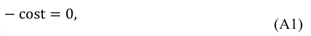

NOTE: contains mathematical notation; text above is the PDF text layer and symbols may be mis-extracted. Image shows the original.

where β is the effect on the average household’s weekly expenditure at the retailer, margin is the

retailer’s net profit margin, and cost is the cost of printing and distributing a store flyer.<sup>26</sup>

Because store flyers are an untargeted channel though, and we estimate our model with

households that visited Lidl at least once in the past two years, we need to adjust for our sample.

We scale the difference in profit by C, the proportion of households that visited Lidl at least once

in the past two years:

**equation / math rendering (image)**

NOTE: contains mathematical notation; text above is the PDF text layer and symbols may be mis-extracted. Image shows the original.

**equation / math rendering (image)**

NOTE: contains mathematical notation; text above is the PDF text layer and symbols may be mis-extracted. Image shows the original.

**equation / math rendering (image)**

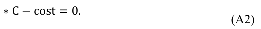

NOTE: contains mathematical notation; text above is the PDF text layer and symbols may be mis-extracted. Image shows the original.

Thus, if β ∗margin ∗C is higher than the cost of printing and distributing a store flyer, cost, then

distributing store flyers is still profitable. Conversely, if β ∗margin ∗C is lower than cost, the

retailer can save money by retiring the store flyer.

26 In addition to printing and distribution, the retailer incurs design costs. However, because the store flyer often remains available in-store and the digital flyer often uses the same design, we do not consider design costs here. Furthermore, design costs are negligible in comparison with printing and distribution costs (Adformatie 2020).

We compute β using our data and estimates,<sup>27</sup> and we set C to be .80, also based on our

data. The average net profit margin for grocery retailers is about 3% to 4% (McKinsey 2023a;

2023b), though substantial heterogeneity exists, so we use a 1%–6% range. The weekly cost of

distributing a store flyer is about 2 cents per flyer, assuming a medium to large print run,

according to information provided by the largest distributor in the Netherlands (Spotta

Foldergemak<sup>28</sup>) but can reach 6 cents for a more limited print run in one local market (Distrifood

2023b). Therefore, we use a 2–6 cents range.

27 In line with the main analysis, we use the average treatment effect. Theoretically, we could consider a subgroup or individual households to calculate the optimal policy, as we note in the “Limitations and Further Research” section. 28 For more information about costs, see https://web.archive.org/web/20240518191813/https://www.foldergemak.nl/klantenservice, “Wat kost een folderverspreiding?” (“How much does flyer distribution cost?”).

#### **WEB APPENDICES FOR**

#### **RETIRING THE STORE FLYER: EFFECTS OF CEASING PRINT STORE FLYERS**

#### **ON HOUSEHOLD GROCERY SHOPPING BEHAVIOR**

#### **Table of Contents**

| WEBAPPENDIX A: COMPARISON OFTREATED PROVINCEAND CONTROL PROVINCES | p 2 . |
| --- | --- |
| WEBAPPENDIX B:COMPOSITION OFTREATED AND CONTROLSAMPLES | p 4 . |
| WEBAPPENDIX C:PRE -TREATMENTTRENDS | p 6 . |
| WEBAPPENDIX D:DID ESTIMATES FOR LIDLAND ALLOTHER RETAILERS | p 9 . |
| WEBAPPENDIX E:RESULTS OFROBUSTNESS CHECKS AND PLACEBO TESTS | p 10 . |

NOTE: table converted from PDF layout to HTML text; cell boundaries are reconstructed. See PDF if exact alignment matters.

#### **WEB APPENDIX A: COMPARISON OF TREATED PROVINCE AND CONTROL**

#### **PROVINCES**

In Table W1, we compare the treated province of Utrecht with the 11 other provinces on

seven dimensions: (1) store density and average distance to the nearest supermarket, (2)

urbanization rate, (3) home ownership rate, (4) mobility (measured as the number of passenger

cars per 1,000 inhabitants), (5) household composition (% of single-person households and

households with children), (6) social security and unemployment rates, (7) ethnic background (%

of Western and non-Western immigrants). Utrecht (UT) does not exhibit extreme values for any

of the characteristics and its values are largely representative of the broader pattern observed

across provinces. Lidl picked Utrecht as a test market because of its high urbanization rate.

While its urbanization rate is indeed relatively high it is comparable to that of other urban

provinces like North Holland (NH) and South Holland (ZH). As such, Utrecht is representative

of a very large part of the Netherlands and for many other urban areas for that matter.

#### **TABLE WA1: COMPARISON OF TREATED PROVINCE AND CONTROL**

#### **PROVINCES**

|  | Treated |  |  |  |  | Control |  |  |  |  |
| --- | --- | --- | --- | --- | --- | --- | --- | --- | --- | --- |
|  | UT | NH | ZH | DR | FL | FR GL GR | LB | NB | OV | ZE |
| Lidlstoredensitya Storedensityother | 21 . 16 . | 20 . 15 . | 23 . 16 . | 34 . 46 . | 22 . 18 . | 30 27 32 . . . 38 35 43 . . . | 29 . 36 . | 29 . 31 . | 29 . 45 . | 38 . 49 . |
| HD Storedensityother | 170 . | 179 . | 165 . | 202 . | 155 . | 239 181 203 . . . | 187 . | 181 . | 182 . | 222 . |
| majorcompetitorsb Averagedistanceto | 9 . | 8 . | 8 . | 14 . | 10 . | 14 11 12 . . . | 10 . | 10 . | 11 . | 12 . |
| nearestsupermarketc Urbanizationrate(%) Homeownershiprate | 908 . 578 . | 923 . 501 . | 943 . 520 . | 553 . 661 . | 872 . 645 . | 557 777 666 . . . 621 609 541 . . . | 757 . 602 . | 827 . 609 . | 777 . 610 . | 621 . 668 . |
| (%) No ofpassengercars . | 410 | 379 | 393 | 523 | 429 | 493 474 448 | 510 | 485 | 468 | 511 |
| per1000inhabitants , %single-person | 392 . | 434 . | 411 . | 341 . | 329 . | 377 371 465 . . . | 396 . | 369 . | 362 . | 375 . |
| households %households with | 333 . | 307 . | 325 . | 326 . | 401 . | 317 327 257 . . . | 286 . | 325 . | 343 . | 302 . |
| children Socialsecurityrate | 66 . | 75 . | 75 . | 82 . | 75 . | 76 73 92 . . . | 91 . | 70 . | 78 . | 65 . |
| (%)d Unemploymentrate | 34 . | 39 . | 39 . | 31 . | 37 . | 36 32 40 . . . | 35 . | 33 . | 33 . | 29 . |
| (%)e %ofWestern | 93 . | 141 . | 123 . | 58 . | 104 . | 53 81 88 . . . | 153 . | 104 . | 73 . | 131 . |
| immigrants %ofnon-Western immigrants | 150 . | 208 . | 220 . | 51 . | 240 . | 55 87 87 . . . | 78 . | 105 . | 91 . | 67 . |

NOTE: table converted from PDF layout to HTML text; cell boundaries are reconstructed. See PDF if exact alignment matters.

a Store density is computed as the number of stores per 100,000 inhabitants. b Major competitors include the nine largest supermarket chains next to Lidl and the other HD. c Average distance across all inhabitants. Supermarkets include all stores larger than 150 m2. d Percentage of people that receive unemployment, social assistance, or disability benefits. e Percentage of unemployed people out of the total labor force. Notes: All data are obtained from Statistics Netherlands, except for the store numbers who are obtained from DPG Media Group.

#### **WEB APPENDIX B: COMPOSITION OF TREATED AND CONTROL SAMPLES**

Table WA2 shows the demographics of treated and control households. Then, Table

WA3 shows descriptive statistics of demographics and weekly shopping behavior at Lidl across

households that have visited Lidl in the data period and that receive store flyers (across treated

and control provinces). This includes households that could not be included in the sample

because of panel attrition or because they joined the panel later. Comparing the 172 treated

households included in our sample with this larger sample of Lidl customers shows that the

treated households in our sample are representative of the larger group of Lidl customers.

#### **TABLE WA2: DEMOGRAPHICS TREATED AND CONTROL HOUSEHOLDS**

**Treated (N = 172) Control (N = 2,600) Mean SD Min Max Mean SD Min Max** Household size<sup>a</sup> 2.38 1.15 1 5 2.42 1.15 1 5 Age of head of household<sup>b</sup> 7.55 1.96 2 11 7.23 2.14 1 11 Income class<sup>c</sup> 13.81 5.74 3 22 13.93 5.93 1 22 Social class<sup>d</sup> 3.96 1.80 1 6 4.09 1.71 1 6 a 1 = 1 household member, 2 = 2 household members, 3 = 3 household members, 4 = 4 household members, 5 = 5 or more household members. b 1 = 12-19 y.o. (years old), 2 = 20-24 y.o., 3 = 25-29 y.o., 4 = 30-34 y.o., 5 = 35-39 y.o., 6 = 40-44 y.o., 7 = 45-49 y.o., 8 = 50-54 y.o., 9 = 55-64 y.o., 10 = 65-74 y.o., 11 = 75 y.o. or older. c Net income per month: 1 = below 700, 2 = 700-900, 3 = 900-1,100, 4 = 1,100-1,300, 5 = 1,300-1,500, 6 = 1,500- 1,700, 7 = 1,700-1,900, 8 = 1,900-2,100, 9 = 2,100-2,300, 10 = 2,300-2,500, 11 = 2,500-2,700, 12 = 2,700-2,900, 13 = 2,900-3,100, 14 = 3,100-3,300, 15 = 3,300-3,500, 16 = 3,500-3,700, 17 = 3,700-3,900, 18 = 3,900-4,100, 19 = 4,100 or more. d 1 = D (lower), 2 = C, 3 = B-minus, 4 = B-plus, 5 = A (upper); based on the education level and occupation of the head of the household.

|  | Treated (N =172) |  |  |  | Control(N =2600) , |  |  |  |
| --- | --- | --- | --- | --- | --- | --- | --- | --- |
|  | Mean | SD | Min | Max | Mean | SD | Min | Max |
| Householdsizea Ageofhead ofhouseholdb Incomeclassc Socialclassd | 238 . 755 . 1381 . 396 . | 115 . 196 . 574 . 180 . | 1 2 3 1 | 5 11 22 6 | 242 . 723 . 1393 . 409 . | 115 . 214 . 593 . 171 . | 1 1 1 1 | 5 11 22 6 |

NOTE: table converted from PDF layout to HTML text; cell boundaries are reconstructed. See PDF if exact alignment matters.

#### **TABLE WA3: DESCRIPTIVE STATISTICS ALL LIDL CUSTOMERS THAT RECEIVE**

#### **STORE FLYERS (N = 3,941)**

#### **A: DEMOGRAPHICS**

|  | Mean | SD | Min | Max |
| --- | --- | --- | --- | --- |
| Householdsize Ageofhead ofhousehold Incomeclass Socialclass | 237 . 714 . 1367 . 411 . | 115 . 225 . 597 . 172 . | 1 1 1 1 | 5 11 22 6 |

NOTE: table converted from PDF layout to HTML text; cell boundaries are reconstructed. See PDF if exact alignment matters.

|  | Mean | SD | Min | Max |
| --- | --- | --- | --- | --- |
| Numberofshoppingtrips | 51 . | 78 . | 0 | 7 |
| Groceryexpenditure(in€s) Numberofunits Expenditureonpromotion(in€s) | 1355 . 1141 . 214 . | 2441 . 2121 . 534 . | 0 0 0 | 37840 . 280 16298 . |
| Numberofunits onpromotion Expenditurenotonpromotion(in€s) Numberofunits notonpromotion | 164 . 1140 . 977 . | 471 . 2125 . 1871 . | 0 0 0 | 165 37840 . 277 |

NOTE: table converted from PDF layout to HTML text; cell boundaries are reconstructed. See PDF if exact alignment matters.

#### **WEB APPENDIX C: PRE-TREATMENT TRENDS**

#### **FIGURE WA1: PRE-TREATMENT TRENDS**

#### **A. LIDL**

#### **A: LOG(NUMBER OF**

#### **SHOPPING TRIPS)**

#### **B: LOG(GROCERY**

#### **EXPENDITURE)**

#### **C: LOG(NUMBER OF**

#### **UNITS)**

#### **D: LOG(EXPENDITURE ON**

#### **PROMOTION)**

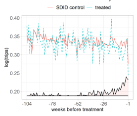

NOTE: figure/graphic rendered as an image from the PDF; its content is not machine-readable text. Caption (if any) follows as the next block.

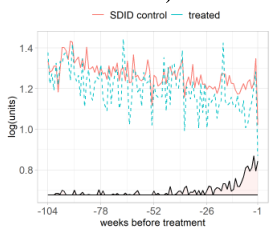

NOTE: figure/graphic rendered as an image from the PDF; its content is not machine-readable text. Caption (if any) follows as the next block.

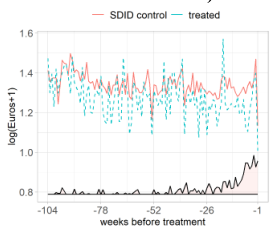

NOTE: figure/graphic rendered as an image from the PDF; its content is not machine-readable text. Caption (if any) follows as the next block.

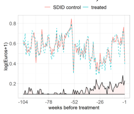

NOTE: figure/graphic rendered as an image from the PDF; its content is not machine-readable text. Caption (if any) follows as the next block.

**E: LOG(NUMBER OF UNITS**

#### **ON PROMOTION)**

#### **F: LOG(EXPENDITURE NOT**

#### **ON PROMOTION)**

#### **G: LOG(NUMBER OF UNITS**

#### **NOT ON PROMOTION)**

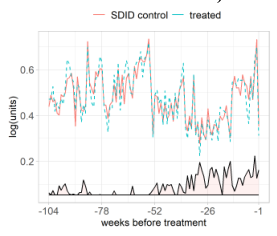

NOTE: figure/graphic rendered as an image from the PDF; its content is not machine-readable text. Caption (if any) follows as the next block.

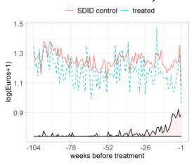

NOTE: figure/graphic rendered as an image from the PDF; its content is not machine-readable text. Caption (if any) follows as the next block.

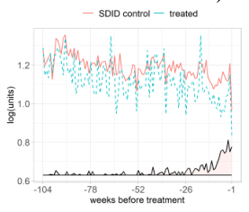

NOTE: figure/graphic rendered as an image from the PDF; its content is not machine-readable text. Caption (if any) follows as the next block.

#### **FIGURE WA1 (CONTINUED)**

#### **B. ALL OTHER RETAILERS**

#### **A: LOG(NUMBER OF**

#### **SHOPPING TRIPS)**

#### **B: LOG(GROCERY**

#### **EXPENDITURE)**

#### **C: LOG(NUMBER OF**

#### **UNITS)**

#### **D: LOG(EXPENDITURE ON**

#### **PROMOTION)**

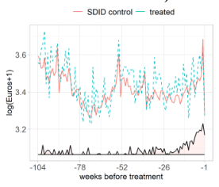

NOTE: figure/graphic rendered as an image from the PDF; its content is not machine-readable text. Caption (if any) follows as the next block.

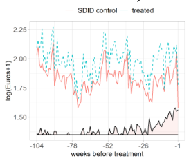

NOTE: figure/graphic rendered as an image from the PDF; its content is not machine-readable text. Caption (if any) follows as the next block.

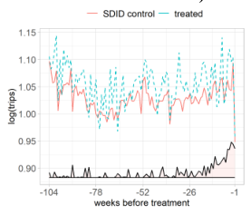

NOTE: figure/graphic rendered as an image from the PDF; its content is not machine-readable text. Caption (if any) follows as the next block.

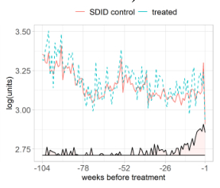

NOTE: figure/graphic rendered as an image from the PDF; its content is not machine-readable text. Caption (if any) follows as the next block.

**E: LOG(NUMBER OF UNITS**

#### **ON PROMOTION)**

#### **F: LOG(EXPENDITURE NOT**

#### **ON PROMOTION)**

#### **G: LOG(NUMBER OF UNITS**

#### **NOT ON PROMOTION)**

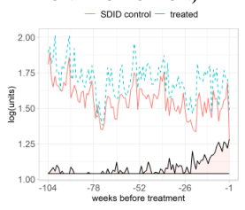

NOTE: figure/graphic rendered as an image from the PDF; its content is not machine-readable text. Caption (if any) follows as the next block.

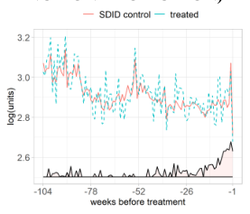

NOTE: figure/graphic rendered as an image from the PDF; its content is not machine-readable text. Caption (if any) follows as the next block.

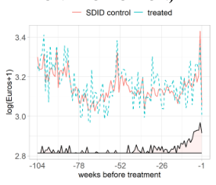

NOTE: figure/graphic rendered as an image from the PDF; its content is not machine-readable text. Caption (if any) follows as the next block.

Notes: Dashed (solid) lines represent the weekly average for treated (control) households. The weighted average for the SDID control households is weighted as described in the “Synthetic Difference-in-Differences” section. The time weights used to average the pre-treatment periods in the SDID approach are at the bottom of each plot.

#### **TABLE WA4: PRE-TREATMENT CORRELATION, TREATED AND CONTROL**

|  | Lidl |  |  |  | AllOtherRetailers |  |
| --- | --- | --- | --- | --- | --- | --- |
|  | Raw |  | SDID |  | Raw | SDID |
| Log(Numberofshoppingtrips) | 37 . |  | 58 . |  | 66 . | 77 . |
| Log(Groceryexpenditure) | 49 . |  | 66 . |  | 78 . | 85 . |
| Log(Numberofunits) | 46 . |  | 62 . |  | 79 . | 86 . |
| Log(Expenditureonpromotion) | 82 . |  | 87 . |  | 83 . | 87 . |
| Log(Numberofunits onpromotion) | 86 . |  | 89 . |  | 81 . | 87 . |
| Log(Expenditurenotonpromotion) | 55 . |  | 69 . |  | 73 . | 82 . |
| Log(Numberofunits notonpromotion) | 53 . |  | 66 . |  | 74 . | 82 . |
| Average | 58 . |  | 71 . |  | 76 . | 84 . |
| Notes: For SDID the control households are weighted as described in the “Synthetic Difference-in-Differences” , |  |  |  |  |  |  |
| section . |  |  |  |  |  |  |

NOTE: table converted from PDF layout to HTML text; cell boundaries are reconstructed. See PDF if exact alignment matters.

#### **WEB APPENDIX D: DID ESTIMATES FOR LIDL AND ALL OTHER RETAILERS**

#### **TABLE WA5: DID ESTIMATES WEEKLY SHOPPING BEHAVIOR AT LIDL AND**

#### **ALL OTHER RETAILERS**

|  |  | Lidl |  | AllOtherRetailers |  |  |
| --- | --- | --- | --- | --- | --- | --- |
|  | 𝛕" | SE | p | 𝛕" | SE | p |
| Log(Numberof shoppingtrips) | 030 -. | 005 . | 2e-9 | 015 . | 006 . | 014 . |
| Log(Groceryexpenditure) Log(Numberofunits) Log(Expenditureonpromotion) | 114 -. 102 -. 060 -. | 020 . 019 . 013 . | 2e-8 1e-7 2e-6 | 056 . 066 . 064 . | 017 . 016 . 018 . | 001 . 1e-4 3e-4 |
| Log(Numberofunits on promotion) Log(Expenditurenotonpromotion) Log(Numberofunits notonpromotion) | 047 -. 097 -. 087 -. | 011 . 019 . 018 . | 3e-5 5e-7 1e-6 | 054 . 055 . 068 . | 016 . 017 . 016 . | 001 . 001 . 3e-5 |

NOTE: table converted from PDF layout to HTML text; cell boundaries are reconstructed. See PDF if exact alignment matters.

#### **WEB APPENDIX E: RESULTS OF ROBUSTNESS CHECKS AND PLACEBO TESTS**

Figure WA2 presents the results of the five robustness checks (two alternative control groups,

opt-out municipalities only, dropping four weeks before, dropping four weeks after) for shopping

behavior at Lidl (Panel A) and other retailers (Panel B). The points estimates are very

comparable across the different analyses. In the robustness check with the alternative control

group, some estimates have higher p-values, likely due to the decrease in statistical power,

resulting from the diminished number of households in the control group (from 2,600 to 159) in

this robustness check. However, across all robustness checks, we find consistent support for the

findings in the main analysis and thus confirm their robustness.

#### **FIGURE WA2: RESULTS OF ROBUSTNESS CHECKS**

#### **A. LIDL**

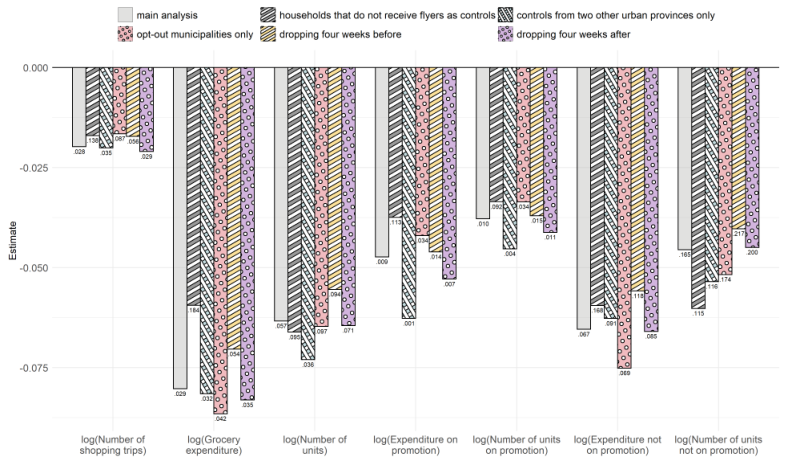

NOTE: figure/graphic rendered as an image from the PDF; its content is not machine-readable text. Caption (if any) follows as the next block.

#### **B. ALL OTHER RETAILERS**

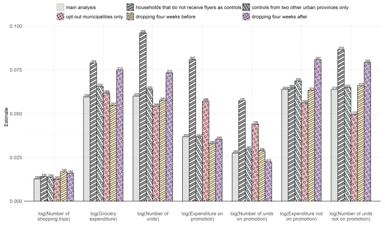

NOTE: figure/graphic rendered as an image from the PDF; its content is not machine-readable text. Caption (if any) follows as the next block.

Notes: Numbers below/above bars indicate p-values. Total number of observations in main analysis (no. of households ´ 130 weeks): 360,360; in the analysis with households that do not receive flyers as controls: 43,030; in the analysis with controls from two other urban provinces only: 124,670; in the analyses with opt-out municipalities only: 310,570; in the analyses dropping four weeks preceding/following the implementation: 349,272.

Figure WA3 presents the results of the placebo test, which compares households residing

in the Utrecht province that do not receive store flyers with households residing in other

provinces that do not receive store flyers. As expected, these results show no differences in

household grocery shopping behavior.

#### **FIGURE WA3: RESULTS OF PLACEBO TEST**

#### **A. LIDL**

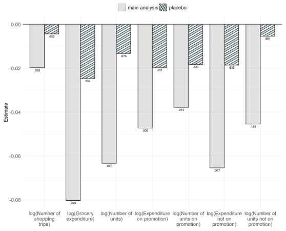

NOTE: figure/graphic rendered as an image from the PDF; its content is not machine-readable text. Caption (if any) follows as the next block.

#### **B. ALL OTHER RETAILERS**

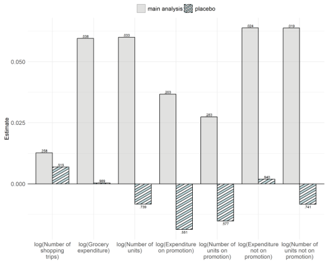

NOTE: figure/graphic rendered as an image from the PDF; its content is not machine-readable text. Caption (if any) follows as the next block.

Notes: Numbers below/above bars indicate p-values. Total number of observations (no. of households ´ 130 weeks): 224,640.